# GRD: hospital epidemiology and diagnostic trajectories of autism

- Show All Code
- Hide All Code
- View Source

Discharges with an F84 code · 2019–2024 · person, place, time, hospitalisation characteristics and prior diagnoses

Published

September 15, 2026

Home Methods REM GRD v01 v02 corpus v05 v06 v07 v10 results

**Show the code that produced this**

```python
from pathlib import Path
import sys
import numpy as np
import pandas as pd
import matplotlib.pyplot as plt
from scipy import stats

ROOT = Path.cwd().parent if Path.cwd().name == "docs" else Path.cwd()
sys.path.insert(0, str(ROOT / "scripts"))
from report_helpers import (read_result, show_table, kpis, note, number, ci, pct, share, plot_style, weighted_quantile,
                            icd_label, icd_chapter, mental_block, load_comunas, load_regions, choropleth, cluster_map,
                            POSITION_LABELS, ROLE_ORDER, DEFINITION_LABELS, GROUP_LABELS, SUBCODE_LABELS, AGE_GROUPS,
                            AGE_BANDS, LOS_BINS, SEX_LABELS, SEX_COLORS, MONTHS, REGION_NAMES, REGION_ORDER, COLORS,
                            CLUSTER_LABELS)
from epi_helpers import direct_standardization

DEFINITION = "TEA_operacional"
ERA = "2021-2024"
YEARS = list(range(2019, 2025))
plot_style()

quality = read_result("grd_epi_quality.csv")
positions_year = read_result("grd_annual_positions.csv")
rates = read_result("grd_rates_national.csv")
age_specific = read_result("grd_rates_age_specific.csv")
sex_ratio = read_result("grd_sex_ratio.csv")
trends = read_result("grd_trends_apc.csv")
subcode_rates = read_result("grd_rates_subcodes.csv")
subcodes = read_result("grd_epi_subcodes.csv")
monthly = read_result("grd_epi_monthly.csv")
age_single = read_result("grd_epi_age_single.csv")
features = read_result("grd_epi_features.csv")
los = read_result("grd_epi_los.csv")
grd_weight = read_result("grd_epi_grd_weight.csv")
hospitals = read_result("grd_epi_hospitals.csv")
codiagnoses = read_result("grd_epi_codiagnoses.csv")
readmissions = read_result("grd_epi_readmissions.csv")
multiplicity = read_result("grd_epi_multiplicity.csv")
regional = read_result("grd_rates_regional.csv")
comunal = read_result("grd_rates_comunal.csv")
moran = read_result("grd_spatial_moran.csv")
lisa = read_result("grd_spatial_lisa.csv")

main_rates = rates.loc[(rates.definition == DEFINITION) & (rates.role == "cualquiera")].copy()
records_total = main_rates.loc[(main_rates.unit == "records") & (main_rates.sex == "TOTAL")].set_index("year")
persons_total = main_rates.loc[(main_rates.unit == "persons") & (main_rates.sex == "TOTAL")].set_index("year")
last_year = int(records_total.index.max())
first_year = int(records_total.index.min())
apc_total = trends.loc[(trends.definition == DEFINITION) & (trends.unit == "records") & (trends.role == "cualquiera")
                       & (trends.sex == "TOTAL") & (trends.period == "2019-2024")].iloc[0]
ratio_last = sex_ratio.loc[(sex_ratio.definition == DEFINITION) & (sex_ratio.unit == "records") & (sex_ratio.role == "cualquiera")
                           & (sex_ratio.year == last_year)].iloc[0]

summary = read_result("grd_cohort_summary.csv")
core = summary.loc[summary.definition == DEFINITION].copy()
cohort = core.loc[core.era == ERA].iloc[0]
n_cohort = int(cohort.patients)
n_prior = int(cohort.prior_hospitalization)

def selected(frame):
    return frame.loc[(frame.definition == DEFINITION) & (frame.era == ERA)].copy()

kpis([
    (number(quality.records_kept.sum()), "Records with an F84 code · 2019–2024"),
    (number(records_total.loc[last_year, "asr"], 1), f"ASD hospitalisations per 100 000 person-years, age-standardised · {last_year}"),
    (number(apc_total.apc, 1) + "%", "Average annual percent change · 2019–2024"),
    (number(ratio_last.asr_ratio, 2), f"Male:female ratio of age-standardised rates · {last_year}"),
    (number(n_cohort), "Identifiers in the trajectory cohort · 2021–2024"),
])
```

**25,620**Records with an F84 code · 2019–2024

**59.2**ASD hospitalisations per 100 000 person-years, age-standardised · 2024

**40.5%**Average annual percent change · 2019–2024

**2.03**Male:female ratio of age-standardised rates · 2024

**15,493**Identifiers in the trajectory cohort · 2021–2024

This report has two parts. **Part A** describes the epidemiology of hospitalisations carrying an autism spectrum disorder (ASD) code in GRD (Grupos Relacionados por el Diagnóstico), the public-hospital discharge database grouped by diagnosis-related groups: how many there are, how they evolve, who has them, where they live, what the episodes look like and which other diagnoses accompany them. **Part B** reconstructs the coding trajectories: which hospital diagnoses appear before the first observed autism record, and in which position it is recorded. Definitions, denominators and methods are in Methods; here only the caveats needed to read each result are repeated.

The main definition is **operational ASD** (F84.0, F84.1, F84.5, F84.8 and F84.9 in any of the 35 diagnostic positions). Rates are expressed per 100 000 person-years of the INE (national statistics institute) population and are age-standardised to the WHO world standard population. **No rate in this report is an incidence or prevalence of autism**: they are rates of hospitalisations, or of hospitalised persons, carrying the code in public facilities with the GRD system.

# Part A. Epidemiology of hospitalisations with an ASD code

## A1. Universe, units and record quality

Each annual file was read in full and the records with any F84 code were kept after removing exact duplicates. A record is an episode of hospitalisation or of major ambulatory surgery. Identifiers allow distinct persons to be counted within each year and within each identifier period (2019–2020 and 2021–2024), but not across the two periods.

**Show the code that produced this**

```python
show_table(quality[["year", "records_scanned", "f84_records", "exact_duplicates_removed", "records_missing_id", "records_missing_sex",
                    "records_invalid_dates", "records_implausible_age", "records_missing_comuna", "records_deaths"]].rename(columns={
    "year": "Year", "records_scanned": "Records read", "f84_records": "With an F84 code", "exact_duplicates_removed": "Exact duplicates",
    "records_missing_id": "Missing identifier", "records_missing_sex": "Missing sex", "records_invalid_dates": "Invalid dates",
    "records_implausible_age": "Implausible age", "records_missing_comuna": "Missing commune", "records_deaths": "Discharge by death",
}), "F84 universe by year and quality checks; causes may overlap")
```

F84 universe by year and quality checks; causes may overlap

| Year | Records read | With an F84 code | Exact duplicates | Missing identifier | Missing sex | Invalid dates | Implausible age | Missing commune | Discharge by death |
| --- | --- | --- | --- | --- | --- | --- | --- | --- | --- |
| 2019 | 1,151,475 | 2,385 | 0 | 4 | 1 | 0 | 0 | 0 | 16 |
| 2020 | 781,912 | 1,633 | 0 | 0 | 0 | 0 | 0 | 0 | 17 |
| 2021 | 816,909 | 2,399 | 0 | 0 | 1 | 0 | 0 | 0 | 7 |
| 2022 | 932,839 | 3,912 | 0 | 3 | 1 | 0 | 0 | 0 | 18 |
| 2023 | 1,039,587 | 6,473 | 0 | 2 | 2 | 0 | 0 | 0 | 21 |
| 2024 | 1,085,813 | 8,818 | 0 | 1 | 4 | 3 | 0 | 0 | 32 |

**Show the code that produced this**

```python
units = positions_year.loc[positions_year.definition == DEFINITION].groupby("source_year")[["records", "identifiers"]].sum()
units_role = positions_year.loc[positions_year.definition == DEFINITION].pivot_table(index="source_year", columns="role", values="records", aggfunc="sum", fill_value=0)
table = units.join(units_role)
table["% principal"] = 100 * (table.get("principal", 0) + table.get("principal_y_secundario", 0)) / table.records
table = table.reset_index().rename(columns={"source_year": "Year", "records": "ASD records", "identifiers": "Distinct identifiers",
                                            "principal": "Principal", "principal_y_secundario": "Principal and secondary", "solo_secundario": "Secondary only"})
show_table(table, "Records and identifiers with an operational ASD code by year and code position", {"% principal": 1})
```

Records and identifiers with an operational ASD code by year and code position

| Year | ASD records | Distinct identifiers | Principal | Principal and secondary | Secondary only | % principal |
| --- | --- | --- | --- | --- | --- | --- |
| 2019 | 2,320 | 1,971 | 221 | 6 | 2,093 | 9.8 |
| 2020 | 1,598 | 1,335 | 152 | 5 | 1,441 | 9.8 |
| 2021 | 2,355 | 1,971 | 183 | 3 | 2,169 | 7.9 |
| 2022 | 3,848 | 3,270 | 286 | 8 | 3,554 | 7.6 |
| 2023 | 6,404 | 5,266 | 351 | 7 | 6,046 | 5.6 |
| 2024 | 8,715 | 7,242 | 372 | 15 | 8,328 | 4.4 |

Distinct identifiers from one year are not added across years: the same person may be hospitalised in several years. In most episodes the autism code occupies a secondary position; the coded reason for the hospitalisation is another one (see A7).

## A2. Time: annual trend, rates and seasonality

**Show the code that produced this**

```python
def rate_table(unit):
    frame = main_rates.loc[main_rates.unit == unit].copy()
    frame["Sex"] = frame.sex.map(SEX_LABELS)
    frame["95% CI crude rate"] = [ci(lo, hi) for lo, hi in zip(frame.crude_lo, frame.crude_hi)]
    frame["95% CI ASR"] = [ci(lo, hi) for lo, hi in zip(frame.asr_lo, frame.asr_hi)]
    return frame.sort_values(["year", "sex"])[["year", "Sex", "count", "population", "crude", "95% CI crude rate", "asr", "95% CI ASR"]].rename(columns={
        "year": "Year", "count": "Records" if unit == "records" else "Persons", "population": "Population",
        "crude": "Crude rate", "asr": "ASR (WHO)"})

show_table(rate_table("records"), "Hospitalisations with an ASD code per 100 000 person-years, crude and age-standardised (ASR), by sex",
           {"Crude rate": 1, "ASR (WHO)": 1})
```

Hospitalisations with an ASD code per 100 000 person-years, crude and age-standardised (ASR), by sex

| Year | Sex | Records | Population | Crude rate | 95% CI crude rate | ASR (WHO) | 95% CI ASR |
| --- | --- | --- | --- | --- | --- | --- | --- |
| 2019 | Males | 1,779 | 9,424,139 | 18.9 | 18.0 to 19.8 | 23.7 | 22.6 to 24.8 |
| 2019 | Females | 544 | 9,683,077 | 5.6 | 5.2 to 6.1 | 7.6 | 6.9 to 8.2 |
| 2019 | Both sexes | 2,323 | 19,107,216 | 12.2 | 11.7 to 12.7 | 15.8 | 15.1 to 16.4 |
| 2020 | Males | 1,199 | 9,599,101 | 12.5 | 11.8 to 13.2 | 15.9 | 15.0 to 16.8 |
| 2020 | Females | 399 | 9,859,209 | 4.0 | 3.7 to 4.5 | 5.5 | 4.9 to 6.0 |
| 2020 | Both sexes | 1,598 | 19,458,310 | 8.2 | 7.8 to 8.6 | 10.7 | 10.2 to 11.3 |
| 2021 | Males | 1,799 | 9,708,512 | 18.5 | 17.7 to 19.4 | 23.7 | 22.6 to 24.8 |
| 2021 | Females | 555 | 9,969,851 | 5.6 | 5.1 to 6.0 | 7.6 | 7.0 to 8.2 |
| 2021 | Both sexes | 2,354 | 19,678,363 | 12.0 | 11.5 to 12.5 | 15.8 | 15.1 to 16.4 |
| 2022 | Males | 2,880 | 9,782,978 | 29.4 | 28.4 to 30.5 | 38.5 | 37.1 to 40.0 |
| 2022 | Females | 970 | 10,045,585 | 9.7 | 9.1 to 10.3 | 13.3 | 12.5 to 14.2 |
| 2022 | Both sexes | 3,850 | 19,828,563 | 19.4 | 18.8 to 20.0 | 26.2 | 25.3 to 27.0 |
| 2023 | Males | 4,486 | 9,848,466 | 45.6 | 44.2 to 46.9 | 60.5 | 58.7 to 62.3 |
| 2023 | Females | 1,918 | 10,112,423 | 19.0 | 18.1 to 19.8 | 26.2 | 25.1 to 27.5 |
| 2023 | Both sexes | 6,404 | 19,960,889 | 32.1 | 31.3 to 32.9 | 43.7 | 42.6 to 44.8 |
| 2024 | Males | 5,839 | 9,910,500 | 58.9 | 57.4 to 60.4 | 78.9 | 76.9 to 80.9 |
| 2024 | Females | 2,870 | 10,175,877 | 28.2 | 27.2 to 29.3 | 38.9 | 37.4 to 40.3 |
| 2024 | Both sexes | 8,709 | 20,086,377 | 43.4 | 42.5 to 44.3 | 59.2 | 58.0 to 60.5 |

**Show the code that produced this**

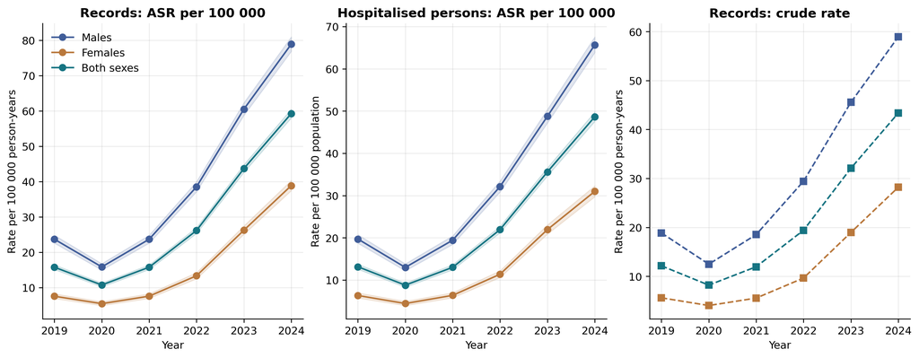

Figure 1: Records and persons with an ASD code per 100 000 person-years: age-standardised rates with 95% confidence intervals (gamma method) and crude rates.

```python
fig, axes = plt.subplots(1, 3, figsize=(12, 4.6), layout="constrained")
for sex, color in [("HOMBRE", SEX_COLORS["HOMBRE"]), ("MUJER", SEX_COLORS["MUJER"]), ("TOTAL", SEX_COLORS["TOTAL"])]:
    frame = main_rates.loc[(main_rates.unit == "records") & (main_rates.sex == sex)].sort_values("year")
    axes[0].plot(frame.year, frame.asr, "o-", color=color, label=SEX_LABELS[sex])
    axes[0].fill_between(frame.year, frame.asr_lo, frame.asr_hi, color=color, alpha=.15)
    frame_p = main_rates.loc[(main_rates.unit == "persons") & (main_rates.sex == sex)].sort_values("year")
    axes[1].plot(frame_p.year, frame_p.asr, "o-", color=color, label=SEX_LABELS[sex])
    axes[1].fill_between(frame_p.year, frame_p.asr_lo, frame_p.asr_hi, color=color, alpha=.15)
    axes[2].plot(frame.year, frame.crude, "s--", color=color, label=SEX_LABELS[sex])
axes[0].set(title="Records: ASR per 100 000", xlabel="Year", ylabel="Rate per 100 000 person-years", xticks=YEARS)
axes[1].set(title="Hospitalised persons: ASR per 100 000", xlabel="Year", ylabel="Rate per 100 000 population", xticks=YEARS)
axes[2].set(title="Records: crude rate", xlabel="Year", ylabel="Rate per 100 000 person-years", xticks=YEARS)
axes[0].legend()
plt.show()
```

The 2020 drop coincides with the general reduction in hospital activity during the pandemic. From 2021 onwards the rate rises every year; growth is greater among females, which lowers the sex ratio (A3). Standardisation changes the ordering of the rates little, because records are concentrated in childhood, but it raises their level relative to the crude rate because of the greater weight of childhood ages in the WHO standard.

**Show the code that produced this**

```python
show_table(rate_table("persons"), "Hospitalised persons with an ASD code per 100 000 population, by year and sex (distinct identifiers within the year)",
           {"Crude rate": 1, "ASR (WHO)": 1})
```

Hospitalised persons with an ASD code per 100 000 population, by year and sex (distinct identifiers within the year)

| Year | Sex | Persons | Population | Crude rate | 95% CI crude rate | ASR (WHO) | 95% CI ASR |
| --- | --- | --- | --- | --- | --- | --- | --- |
| 2019 | Males | 1,478 | 9,424,139 | 15.7 | 14.9 to 16.5 | 19.7 | 18.7 to 20.7 |
| 2019 | Females | 457 | 9,683,077 | 4.7 | 4.3 to 5.2 | 6.3 | 5.8 to 7.0 |
| 2019 | Both sexes | 1,935 | 19,107,216 | 10.1 | 9.7 to 10.6 | 13.1 | 12.6 to 13.7 |
| 2020 | Males | 985 | 9,599,101 | 10.3 | 9.6 to 10.9 | 13.0 | 12.2 to 13.8 |
| 2020 | Females | 324 | 9,859,209 | 3.3 | 2.9 to 3.7 | 4.4 | 4.0 to 5.0 |
| 2020 | Both sexes | 1,309 | 19,458,310 | 6.7 | 6.4 to 7.1 | 8.8 | 8.3 to 9.3 |
| 2021 | Males | 1,475 | 9,708,512 | 15.2 | 14.4 to 16.0 | 19.4 | 18.4 to 20.5 |
| 2021 | Females | 467 | 9,969,851 | 4.7 | 4.3 to 5.1 | 6.4 | 5.8 to 7.0 |
| 2021 | Both sexes | 1,942 | 19,678,363 | 9.9 | 9.4 to 10.3 | 13.0 | 12.4 to 13.6 |
| 2022 | Males | 2,398 | 9,782,978 | 24.5 | 23.5 to 25.5 | 32.1 | 30.8 to 33.4 |
| 2022 | Females | 826 | 10,045,585 | 8.2 | 7.7 to 8.8 | 11.4 | 10.6 to 12.2 |
| 2022 | Both sexes | 3,224 | 19,828,563 | 16.3 | 15.7 to 16.8 | 21.9 | 21.2 to 22.7 |
| 2023 | Males | 3,613 | 9,848,466 | 36.7 | 35.5 to 37.9 | 48.8 | 47.2 to 50.4 |
| 2023 | Females | 1,602 | 10,112,423 | 15.8 | 15.1 to 16.6 | 21.9 | 20.9 to 23.1 |
| 2023 | Both sexes | 5,215 | 19,960,889 | 26.1 | 25.4 to 26.8 | 35.6 | 34.6 to 36.6 |
| 2024 | Males | 4,856 | 9,910,500 | 49.0 | 47.6 to 50.4 | 65.7 | 63.8 to 67.5 |
| 2024 | Females | 2,295 | 10,175,877 | 22.6 | 21.6 to 23.5 | 31.0 | 29.7 to 32.3 |
| 2024 | Both sexes | 7,151 | 20,086,377 | 35.6 | 34.8 to 36.4 | 48.6 | 47.5 to 49.8 |

### Average annual percent change

**Show the code that produced this**

```python
apc = trends.loc[(trends.definition == DEFINITION) & (trends.role == "cualquiera")].copy()
apc["Unit"] = apc.unit.map({"records": "Records", "persons": "Persons"})
apc["Sex"] = apc.sex.map(SEX_LABELS)
apc["95% CI"] = [ci(lo, hi) for lo, hi in zip(apc.apc_lo, apc.apc_hi)]
show_table(apc.sort_values(["Unit", "period", "sex"])[["Unit", "period", "Sex", "apc", "95% CI", "p_value", "dispersion"]].rename(columns={
    "period": "Period", "apc": "AAPC (%)", "p_value": "p value", "dispersion": "Overdispersion factor",
}), "Average annual percent change of the rates (quasi-Poisson model with population offset)", {"AAPC (%)": 1, "p value": 4, "Overdispersion factor": 1})
```

Average annual percent change of the rates (quasi-Poisson model with population offset)

| Unit | Period | Sex | AAPC (%) | 95% CI | p value | Overdispersion factor |
| --- | --- | --- | --- | --- | --- | --- |
| Persons | 2019-2024 | Males | 35.9 | 21.7 to 51.7 | 0.0000 | 113.6 |
| Persons | 2019-2024 | Females | 51.7 | 33.0 to 73.1 | 0.0000 | 57.7 |
| Persons | 2019-2024 | Both sexes | 40.1 | 24.8 to 57.2 | 0.0000 | 170.3 |
| Persons | 2021-2024 | Males | 45.7 | 37.2 to 54.8 | 0.0000 | 12.9 |
| Persons | 2021-2024 | Females | 66.8 | 50.4 to 85.0 | 0.0000 | 14.6 |
| Persons | 2021-2024 | Both sexes | 51.5 | 41.5 to 62.1 | 0.0000 | 22.8 |
| Records | 2019-2024 | Males | 35.9 | 21.9 to 51.6 | 0.0000 | 135.9 |
| Records | 2019-2024 | Females | 53.4 | 34.1 to 75.5 | 0.0000 | 71.8 |
| Records | 2019-2024 | Both sexes | 40.5 | 25.2 to 57.7 | 0.0000 | 205.6 |
| Records | 2021-2024 | Males | 45.4 | 35.1 to 56.4 | 0.0000 | 23.2 |
| Records | 2021-2024 | Females | 70.5 | 55.8 to 86.7 | 0.0000 | 13.3 |
| Records | 2021-2024 | Both sexes | 52.1 | 41.3 to 63.7 | 0.0000 | 32.3 |

The 2019–2024 period includes the 2020 drop and therefore shows very high overdispersion and wide intervals; the 2021–2024 period describes the phase of sustained growth. Neither model separates an increase in occurrence from increases in detection, demand and coding, which changed over the same period (Law 21.545 in 2023).

### Sensitivity to the case definition

**Show the code that produced this**

```python
sens = rates.loc[(rates.unit == "records") & (rates.role == "cualquiera") & (rates.sex == "TOTAL")].pivot(index="year", columns="definition", values="asr")
sens = sens[["autismo_F840", "TEA_operacional", "F84_historico"]].rename(columns=DEFINITION_LABELS).reset_index().rename(columns={"year": "Year"})
show_table(sens, "Age-standardised rate of records per 100 000 by case definition (the definitions overlap; they are not additive)",
           {c: 1 for c in sens.columns if c != "Year"})
```

Age-standardised rate of records per 100 000 by case definition (the definitions overlap; they are not additive)

| Year | Specific autism (F84.0) | Operational ASD (F84.0/.1/.5/.8/.9) | Historical F84 (all subcategories) |
| --- | --- | --- | --- |
| 2019 | 9.5 | 15.8 | 16.2 |
| 2020 | 7.3 | 10.7 | 11.0 |
| 2021 | 12.5 | 15.8 | 16.1 |
| 2022 | 21.0 | 26.2 | 26.6 |
| 2023 | 36.5 | 43.7 | 44.1 |
| 2024 | 49.5 | 59.2 | 59.9 |

### Seasonality and monthly series

**Show the code that produced this**

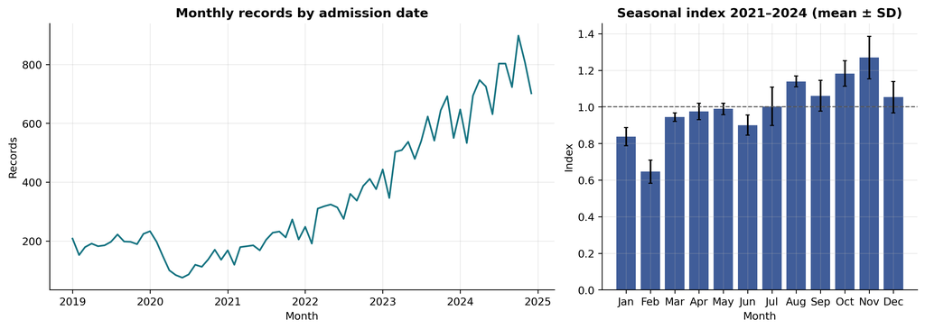

Figure 2: Records with an ASD code by month of admission and seasonal index (monthly mean relative to the year’s monthly mean); 2019–2024, any position.

```python
monthly_main = monthly.loc[monthly.definition == DEFINITION].groupby(["year", "month"]).records.sum().reset_index()
monthly_main["fecha"] = pd.to_datetime(dict(year=monthly_main.year, month=monthly_main.month, day=1))
by_year_mean = monthly_main.groupby("year").records.transform("mean")
monthly_main["index"] = monthly_main.records / by_year_mean
season = monthly_main.loc[monthly_main.year >= 2021].groupby("month")["index"].agg(["mean", "std"]).reindex(range(1, 13))
fig, axes = plt.subplots(1, 2, figsize=(12, 4.2), layout="constrained", gridspec_kw={"width_ratios": [1.6, 1]})
axes[0].plot(monthly_main.fecha, monthly_main.records, color=COLORS[0], linewidth=1.6)
axes[0].set(title="Monthly records by admission date", xlabel="Month", ylabel="Records")
axes[1].bar(range(1, 13), season["mean"], yerr=season["std"], color=COLORS[1], capsize=2)
axes[1].axhline(1, color="#555555", linewidth=1, linestyle="--")
axes[1].set(title="Seasonal index 2021–2024 (mean ± SD)", xlabel="Month", ylabel="Index", xticks=range(1, 13), xticklabels=MONTHS)
plt.show()
```

The seasonal index is calculated within each year so that trend is not confused with seasonality. The lowest values fall in January and February, the school holiday period, and the highest in August to November. The pattern is consistent with the school calendar and with the general seasonality of paediatric hospitalisations; it does not describe seasonality of autism.

## A3. Person: sex and age

### Male:female ratio

**Show the code that produced this**

```python
ratio = sex_ratio.loc[(sex_ratio.definition == DEFINITION) & (sex_ratio.role == "cualquiera")].copy()
ratio["Unit"] = ratio.unit.map({"records": "Records", "persons": "Persons"})
ratio["95% CI ASR ratio"] = [ci(lo, hi, 2) for lo, hi in zip(ratio.asr_ratio_lo, ratio.asr_ratio_hi)]
ratio["95% CI count ratio"] = [ci(lo, hi, 2) for lo, hi in zip(ratio.count_ratio_lo, ratio.count_ratio_hi)]
show_table(ratio.sort_values(["Unit", "year"])[["Unit", "year", "count_men", "count_women", "asr_men", "asr_women", "asr_ratio", "95% CI ASR ratio",
                                                  "count_ratio", "95% CI count ratio"]].rename(columns={
    "year": "Year", "count_men": "Males", "count_women": "Females", "asr_men": "ASR males", "asr_women": "ASR females",
    "asr_ratio": "M:F ASR ratio", "count_ratio": "M:F count ratio",
}), "Male:female ratio of age-standardised rates and of counts, with 95% intervals", {"ASR males": 1, "ASR females": 1, "M:F ASR ratio": 2, "M:F count ratio": 2})
```

Male:female ratio of age-standardised rates and of counts, with 95% intervals

| Unit | Year | Males | Females | ASR males | ASR females | M:F ASR ratio | 95% CI ASR ratio | M:F count ratio | 95% CI count ratio |
| --- | --- | --- | --- | --- | --- | --- | --- | --- | --- |
| Persons | 2019 | 1,478 | 457 | 19.7 | 6.3 | 3.11 | 2.80 to 3.45 | 3.23 | 2.91 to 3.60 |
| Persons | 2020 | 985 | 324 | 13.0 | 4.4 | 2.92 | 2.58 to 3.32 | 3.04 | 2.68 to 3.46 |
| Persons | 2021 | 1,475 | 467 | 19.4 | 6.4 | 3.05 | 2.74 to 3.38 | 3.16 | 2.84 to 3.51 |
| Persons | 2022 | 2,398 | 826 | 32.1 | 11.4 | 2.82 | 2.61 to 3.06 | 2.90 | 2.68 to 3.15 |
| Persons | 2023 | 3,613 | 1,602 | 48.8 | 21.9 | 2.22 | 2.09 to 2.36 | 2.26 | 2.13 to 2.39 |
| Persons | 2024 | 4,856 | 2,295 | 65.7 | 31.0 | 2.12 | 2.02 to 2.23 | 2.12 | 2.01 to 2.22 |
| Records | 2019 | 1,779 | 544 | 23.7 | 7.6 | 3.13 | 2.85 to 3.45 | 3.27 | 2.97 to 3.61 |
| Records | 2020 | 1,199 | 399 | 15.9 | 5.5 | 2.90 | 2.59 to 3.26 | 3.01 | 2.68 to 3.37 |
| Records | 2021 | 1,799 | 555 | 23.7 | 7.6 | 3.12 | 2.84 to 3.44 | 3.24 | 2.95 to 3.57 |
| Records | 2022 | 2,880 | 970 | 38.5 | 13.3 | 2.89 | 2.68 to 3.11 | 2.97 | 2.76 to 3.20 |
| Records | 2023 | 4,486 | 1,918 | 60.5 | 26.2 | 2.31 | 2.18 to 2.43 | 2.34 | 2.22 to 2.47 |
| Records | 2024 | 5,839 | 2,870 | 78.9 | 38.9 | 2.03 | 1.94 to 2.12 | 2.03 | 1.95 to 2.13 |

**Show the code that produced this**

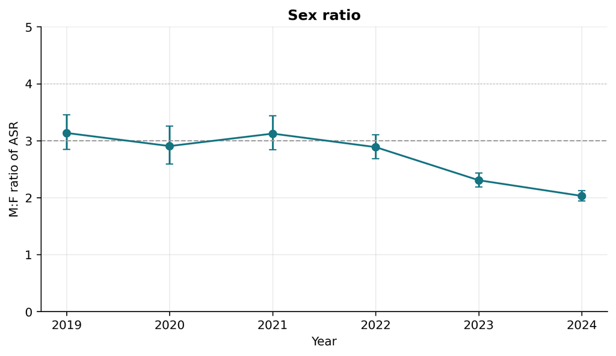

Figure 3: Male:female ratio of the age-standardised rates of records with an ASD code, by year, with 95% interval and literature reference values (3:1 and 4:1).

```python
frame = ratio.loc[ratio.unit == "records"].sort_values("year")
fig, ax = plt.subplots(figsize=(7, 4), layout="constrained")
ax.errorbar(frame.year, frame.asr_ratio, yerr=[frame.asr_ratio - frame.asr_ratio_lo, frame.asr_ratio_hi - frame.asr_ratio], fmt="o-", color=COLORS[0], capsize=3)
ax.axhline(3, color="#999999", linestyle="--", linewidth=1)
ax.axhline(4, color="#cccccc", linestyle=":", linewidth=1)
ax.set(xlabel="Year", ylabel="M:F ratio of ASR", xticks=YEARS, ylim=(0, 5), title="Sex ratio")
plt.show()
```

The sex ratio of hospital records falls from about 3:1 in 2019–2021 to around 2:1 in 2024, owing to the proportionally greater growth of hospitalisations among females. The literature reports ratios close to 3:1 in population-based studies and lower ratios where detection in girls and women improves; a hospital-based ratio also depends on the causes of hospitalisation, which differ by sex.

### Age

**Show the code that produced this**

```python
ages_main = age_single.loc[(age_single.definition == DEFINITION)].groupby(["year", "sex", "age"]).records.sum().reset_index()
rows = []
for (year, sex), group in ages_main.groupby(["year", "sex"]):
    rows.append(dict(Year=year, Sex=SEX_LABELS.get(sex, sex), Records=group.records.sum(),
                     Q1=weighted_quantile(group.age, group.records, .25), Median=weighted_quantile(group.age, group.records, .5),
                     Q3=weighted_quantile(group.age, group.records, .75),
                     **{"% under 10": share(group.loc[group.age < 10].records.sum(), group.records.sum()),
                        "% aged 18 and over": share(group.loc[group.age >= 18].records.sum(), group.records.sum())}))
for year, group in ages_main.groupby("year"):
    rows.append(dict(Year=year, Sex="Both sexes", Records=group.records.sum(),
                     Q1=weighted_quantile(group.age, group.records, .25), Median=weighted_quantile(group.age, group.records, .5),
                     Q3=weighted_quantile(group.age, group.records, .75),
                     **{"% under 10": share(group.loc[group.age < 10].records.sum(), group.records.sum()),
                        "% aged 18 and over": share(group.loc[group.age >= 18].records.sum(), group.records.sum())}))
age_summary = pd.DataFrame(rows).sort_values(["Year", "Sex"])
show_table(age_summary, "Age at admission of records with an ASD code (completed years): quartiles and proportions", {"Q1": 1, "Median": 1, "Q3": 1, "% under 10": 1, "% aged 18 and over": 1})
```

Age at admission of records with an ASD code (completed years): quartiles and proportions

| Year | Sex | Records | Q1 | Median | Q3 | % under 10 | % aged 18 and over |
| --- | --- | --- | --- | --- | --- | --- | --- |
| 2019 | Both sexes | 2,323 | 4.0 | 8.0 | 13.9 | 55.9 | 14.2 |
| 2019 | Females | 544 | 3.0 | 7.7 | 13.1 | 55.1 | 12.9 |
| 2019 | Males | 1,779 | 4.1 | 7.9 | 13.3 | 56.1 | 14.6 |
| 2020 | Both sexes | 1,598 | 4.6 | 10.0 | 14.0 | 48.9 | 15.0 |
| 2020 | Females | 399 | 4.0 | 8.9 | 13.8 | 50.6 | 15.5 |
| 2020 | Males | 1,199 | 4.6 | 9.2 | 14.0 | 48.4 | 14.8 |
| 2021 | Both sexes | 2,354 | 5.0 | 9.9 | 14.0 | 49.3 | 15.6 |
| 2021 | Females | 555 | 4.8 | 10.9 | 13.9 | 41.8 | 15.0 |
| 2021 | Males | 1,799 | 4.7 | 8.7 | 13.7 | 51.6 | 15.8 |
| 2022 | Both sexes | 3,850 | 4.2 | 8.9 | 14.0 | 53.5 | 13.1 |
| 2022 | Females | 970 | 4.0 | 11.0 | 14.2 | 44.7 | 13.9 |
| 2022 | Males | 2,880 | 4.0 | 7.7 | 13.2 | 56.4 | 12.8 |
| 2023 | Both sexes | 6,404 | 4.5 | 9.0 | 14.0 | 51.9 | 12.6 |
| 2023 | Females | 1,918 | 4.9 | 11.5 | 14.9 | 40.1 | 16.0 |
| 2023 | Males | 4,486 | 4.2 | 7.7 | 13.3 | 56.9 | 11.2 |
| 2024 | Both sexes | 8,709 | 5.8 | 10.0 | 14.4 | 47.8 | 15.0 |
| 2024 | Females | 2,870 | 7.0 | 12.5 | 16.0 | 32.5 | 20.9 |
| 2024 | Males | 5,839 | 4.8 | 8.0 | 13.1 | 55.2 | 12.1 |

**Show the code that produced this**

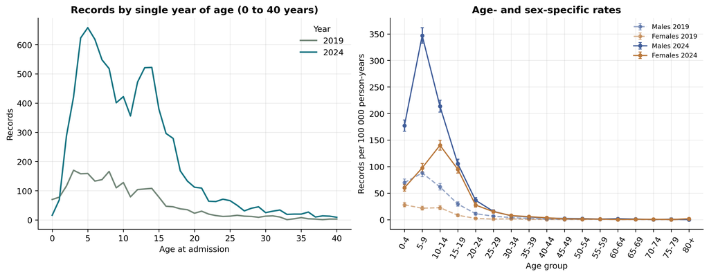

Figure 4: Distribution by single year of age of records with an ASD code (left) and age-specific rates by age group and sex in 2019 and in the latest year (right), with exact Poisson intervals.

```python
fig, axes = plt.subplots(1, 2, figsize=(12, 4.6), layout="constrained")
for year, color in [(first_year, COLORS[3]), (last_year, COLORS[0])]:
    curve = ages_main.loc[(ages_main.year == year) & (ages_main.age <= 40)].groupby("age").records.sum().reindex(range(0, 41), fill_value=0)
    axes[0].plot(curve.index, curve.values, color=color, label=str(year), linewidth=1.8)
axes[0].set(title="Records by single year of age (0 to 40 years)", xlabel="Age at admission", ylabel="Records")
axes[0].legend(title="Year")
spec = age_specific.loc[(age_specific.definition == DEFINITION) & (age_specific.unit == "records")]
order = [g for g in AGE_GROUPS if g in set(spec.age_group)]
x = np.arange(len(order))
for offset, (year, style) in enumerate([(first_year, "--"), (last_year, "-")]):
    for sex in ["HOMBRE", "MUJER"]:
        frame = spec.loc[(spec.year == year) & (spec.sex == sex)].set_index("age_group").reindex(order)
        axes[1].errorbar(x, frame.rate, yerr=[frame.rate - frame.rate_lo, frame.rate_hi - frame.rate], fmt="o" + style, color=SEX_COLORS[sex],
                         alpha=.55 if year == first_year else 1, label=f"{SEX_LABELS[sex]} {year}", capsize=2, markersize=4)
axes[1].set(title="Age- and sex-specific rates", xlabel="Age group", ylabel="Records per 100 000 person-years", xticks=x, xticklabels=order)
axes[1].tick_params(axis="x", rotation=60)
axes[1].legend(fontsize=8)
plt.show()
```

**Show the code that produced this**

```python
spec_last = spec.loc[spec.year == last_year].pivot(index="age_group", columns="sex", values="rate").reindex(order)
counts_last = spec.loc[spec.year == last_year].pivot(index="age_group", columns="sex", values="count").reindex(order)
table = pd.DataFrame({"Age group": order, "Records males": counts_last["HOMBRE"].values, "Records females": counts_last["MUJER"].values,
                      "Rate males": spec_last["HOMBRE"].values, "Rate females": spec_last["MUJER"].values, "Rate both sexes": spec_last["TOTAL"].values})
table["M:F ratio"] = table["Rate males"] / table["Rate females"].replace(0, np.nan)
show_table(table, f"Age-specific rates of records with an ASD code per 100 000 person-years by age group and sex · {last_year}",
           {"Rate males": 1, "Rate females": 1, "Rate both sexes": 1, "M:F ratio": 2})
```

Age-specific rates of records with an ASD code per 100 000 person-years by age group and sex · 2024

| Age group | Records males | Records females | Rate males | Rate females | Rate both sexes | M:F ratio |
| --- | --- | --- | --- | --- | --- | --- |
| 0-4 | 1,068 | 348 | 177.0 | 59.9 | 119.6 | 2.95 |
| 5-9 | 2,158 | 585 | 346.8 | 97.6 | 224.5 | 3.55 |
| 10-14 | 1,404 | 889 | 213.5 | 140.1 | 177.4 | 1.52 |
| 15-19 | 671 | 584 | 105.5 | 95.1 | 100.4 | 1.11 |
| 20-24 | 242 | 177 | 36.6 | 27.6 | 32.1 | 1.33 |
| 25-29 | 120 | 112 | 15.6 | 15.0 | 15.3 | 1.04 |
| 30-34 | 63 | 65 | 7.3 | 7.8 | 7.5 | 0.94 |
| 35-39 | 40 | 44 | 5.1 | 5.7 | 5.4 | 0.89 |
| 40-44 | 22 | 25 | 3.1 | 3.5 | 3.3 | 0.87 |
| 45-49 | 15 | 11 | 2.2 | 1.6 | 1.9 | 1.37 |
| 50-54 | 12 | 8 | 2.0 | 1.3 | 1.6 | 1.54 |
| 55-59 | 7 | 6 | 1.2 | 1.0 | 1.1 | 1.23 |
| 60-64 | 9 | 2 | 1.7 | 0.4 | 1.0 | 4.89 |
| 65-69 | 5 | 3 | 1.2 | 0.6 | 0.9 | 1.89 |
| 70-74 | 1 | 3 | 0.3 | 0.8 | 0.6 | 0.40 |
| 75-79 | 2 | 1 | 0.9 | 0.4 | 0.6 | 2.60 |
| 80+ | 0 | 7 | 0.0 | 1.7 | 1.1 | 0.00 |

The highest rates are observed between 5 and 14 years of age. The male:female ratio is highest in childhood and declines in adolescence and adulthood, a pattern consistent with the evidence on later diagnosis in females, but also with differences in the reasons for hospitalisation by sex and age.

## A4. F84 subcategories and code position

**Show the code that produced this**

```python
sub = subcode_rates.loc[(subcode_rates.sex == "TOTAL") & (subcode_rates.code_position == "cualquiera")].pivot(index="code", columns="year", values="count")
sub_asr = subcode_rates.loc[(subcode_rates.sex == "TOTAL") & (subcode_rates.code_position == "cualquiera") & (subcode_rates.year == last_year)].set_index("code")
sub_principal = subcode_rates.loc[(subcode_rates.sex == "TOTAL") & (subcode_rates.code_position == "principal")].groupby("code")["count"].sum()
table = sub.reindex(list(SUBCODE_LABELS)).dropna(how="all")
table.insert(0, "Subcategory", [SUBCODE_LABELS[c] for c in table.index])
table[f"ASR {last_year}"] = sub_asr.asr.reindex(table.index).values
table[f"95% CI ASR {last_year}"] = [ci(lo, hi, 2) for lo, hi in zip(sub_asr.asr_lo.reindex(table.index), sub_asr.asr_hi.reindex(table.index))]
table["% principal 2019–2024"] = 100 * sub_principal.reindex(table.index).fillna(0) / table[YEARS].sum(axis=1)
show_table(table.reset_index(drop=True), "Records by F84 subcategory and year (a record counts once per subcategory), age-standardised rate of the latest year and proportion with the subcategory in the principal position",
           {f"ASR {last_year}": 2, "% principal 2019–2024": 1})
```

Records by F84 subcategory and year (a record counts once per subcategory), age-standardised rate of the latest year and proportion with the subcategory in the principal position

| Subcategory | 2019 | 2020 | 2021 | 2022 | 2023 | 2024 | ASR 2024 | 95% CI ASR 2024 | % principal 2019–2024 |
| --- | --- | --- | --- | --- | --- | --- | --- | --- | --- |
| F84.0 Childhood autism | 1,399 | 1,084 | 1,847 | 3,061 | 5,323 | 7,227 | 49.48 | 48.34 to 50.64 | 5.7 |
| F84.1 Atypical autism | 101 | 63 | 76 | 111 | 218 | 335 | 2.09 | 1.87 to 2.33 | 19.8 |
| F84.2 Rett syndrome | 55 | 27 | 36 | 57 | 58 | 94 | 0.64 | 0.51 to 0.78 | 14.4 |
| F84.3 Disintegrative disorder | 5 | 4 | 4 | 5 | 5 | 3 | 0.02 | 0.00 to 0.06 | 3.8 |
| F84.4 Overactive disorder with mental retardation and stereotyped movements | 9 | 8 | 10 | 7 | 14 | 15 | 0.10 | 0.06 to 0.17 | 9.5 |
| F84.5 Asperger syndrome | 409 | 214 | 236 | 210 | 161 | 139 | 0.88 | 0.74 to 1.04 | 6.3 |
| F84.8 Other PDD | 189 | 95 | 84 | 134 | 217 | 343 | 2.23 | 2.00 to 2.49 | 6.8 |
| F84.9 PDD, unspecified | 259 | 165 | 133 | 363 | 528 | 717 | 4.89 | 4.54 to 5.27 | 6.2 |

**Show the code that produced this**

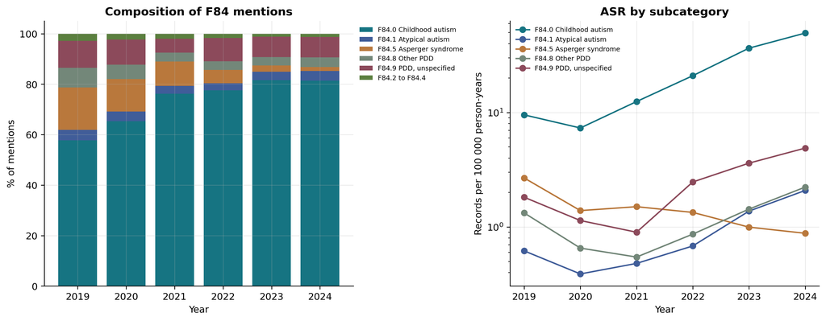

Figure 5: Composition of F84 subcategories by year (percentage of mentions) and age-standardised rate by subcategory; F84.2, F84.3 and F84.4 are grouped because of their low frequency.

```python
mentions = subcodes.groupby(["year", "code"]).records.sum().unstack("code").fillna(0)
mentions["F842-F844"] = mentions[[c for c in ["F842", "F843", "F844"] if c in mentions]].sum(axis=1)
keep = [c for c in ["F840", "F841", "F845", "F848", "F849", "F84", "F842-F844"] if c in mentions]
comp = mentions[keep].div(mentions[keep].sum(axis=1), axis=0) * 100
fig, axes = plt.subplots(1, 2, figsize=(12, 4.6), layout="constrained")
bottom = np.zeros(len(comp))
for code, color in zip(keep, COLORS):
    axes[0].bar(comp.index.astype(str), comp[code], bottom=bottom, color=color, label=SUBCODE_LABELS.get(code, "F84.2 to F84.4"))
    bottom += comp[code].values
axes[0].set(title="Composition of F84 mentions", xlabel="Year", ylabel="% of mentions")
axes[0].legend(fontsize=7, loc="upper left", bbox_to_anchor=(1, 1))
for code, color in zip(["F840", "F841", "F845", "F848", "F849"], COLORS):
    frame = subcode_rates.loc[(subcode_rates.sex == "TOTAL") & (subcode_rates.code_position == "cualquiera") & (subcode_rates.code == code)].sort_values("year")
    axes[1].plot(frame.year, frame.asr, "o-", color=color, label=SUBCODE_LABELS[code])
axes[1].set(title="ASR by subcategory", xlabel="Year", ylabel="Records per 100 000 person-years", xticks=YEARS, yscale="log")
axes[1].legend(fontsize=7)
plt.show()
```

Category F84.0 (childhood autism) accounts for the great majority of mentions and explains the growth; F84.5 (Asperger syndrome) and F84.1 (atypical autism) remain stable or decline in relative terms, in line with the progressive abandonment of those distinctions in clinical practice. The logarithmic scale of the right-hand panel allows subcategories of very different magnitude to be compared.

### Code position within the episode

**Show the code that produced this**

```python
pos = rates.loc[(rates.definition == DEFINITION) & (rates.unit == "records") & (rates.sex == "TOTAL") & (rates.role != "cualquiera")].copy()
pos["Position"] = pos.role.map(POSITION_LABELS)
pivot_n = pos.pivot(index="year", columns="Position", values="count")
pivot_asr = pos.pivot(index="year", columns="Position", values="asr")
table = pivot_n.add_prefix("Records · ").join(pivot_asr.add_prefix("ASR · ")).reset_index().rename(columns={"year": "Year"})
show_table(table, "Records and age-standardised rates by position of the ASD code in the episode", {c: 2 for c in table.columns if c.startswith("ASR")})
```

Records and age-standardised rates by position of the ASD code in the episode

| Year | Records · Principal | Records · Principal and secondary | Records · Secondary only | ASR · Principal | ASR · Principal and secondary | ASR · Secondary only |
| --- | --- | --- | --- | --- | --- | --- |
| 2019 | 221 | 6 | 2,096 | 1.46 | 0.04 | 14.27 |
| 2020 | 152 | 5 | 1,441 | 1.00 | 0.03 | 9.71 |
| 2021 | 183 | 3 | 2,168 | 1.18 | 0.02 | 14.57 |
| 2022 | 286 | 8 | 3,556 | 1.87 | 0.05 | 24.24 |
| 2023 | 351 | 7 | 6,046 | 2.31 | 0.04 | 41.32 |
| 2024 | 371 | 15 | 8,323 | 2.44 | 0.10 | 56.70 |

When the autism code is the principal diagnosis, the hospitalisation has autism as the coded reason for care (for example, behavioural decompensation or assessment). When it is secondary, it describes a condition present during a hospitalisation for another cause; the recent growth occurs mostly in this position, consistent with greater recording of the condition at any hospital contact.

## A5. Hospitalisation characteristics

**Show the code that produced this**

```python
main_features = features.loc[features.definition == DEFINITION].copy()

# English display labels for the producer's categorical values (the data keep the original Spanish categories).
VALUE_LABELS = {
    "HOSPITALIZACIÓN": "Hospitalisation", "HOSPITALIZACIÓN DIURNA": "Day hospitalisation", "HOSPITALIZACIÓN EN URGENCIA": "Emergency hospitalisation",
    "CIRUGÍA MAYOR AMBULATORIA (CMA)": "Major ambulatory surgery (CMA)",
    "URGENCIA": "Emergency", "PROGRAMADA": "Scheduled", "OBSTETRICA": "Obstetric", "NO IDENTIFICADA": "Not identified", "DESCONOCIDO": "Unknown",
    "DOMICILIO": "Home", "FALLECIDO": "Died", "ALTA VOLUNTARIA": "Voluntary discharge", "FUGA DEL PACIENTE": "Patient absconded",
    "HOSPITALIZACIÓN DOMICILIARIA": "Home hospitalisation", "DERIVACIÓN OTRO HOSPITAL DEL SERVICIO": "Referral to another hospital of the health service",
    "DERIVACIÓN OTRO HOSPITAL DE LA RED NACIONAL": "Referral to another hospital of the national network",
    "DERIVACIÓN INST. PRIVADA (VOLUNTARIO)": "Referral to a private institution (voluntary)",
    "DERIVACIÓN INST. PRIVADA (COMPRA DE SERVICIOS": "Referral to a private institution (purchased services)",
    "DERIVACIÓN A OTROS CENTROS (CÁRCEL, HOGAR DE": "Referral to other centres (prison, care home)",
    "FFAA y de Orden": "Armed Forces and Police", "FONASA libre elección": "FONASA free choice", "No identificada": "Not identified", "Particular": "Private (out of pocket)",
    "Chile": "Chile", "Otro país": "Other country", "Desconocida": "Unknown",
    "Ninguno/otro": "None/other", "Pueblo originario declarado": "Indigenous people declared",
}


def feature_table(variable, caption, top=None, labels=None, years=(2019, 2022, last_year)):
    frame = main_features.loc[main_features.variable == variable].groupby(["year", "value"]).records.sum().unstack("year").fillna(0)
    frame["Total 2019–2024"] = frame.sum(axis=1)
    frame = frame.sort_values("Total 2019–2024", ascending=False)
    if top:
        frame = frame.head(top)
    for year in years:
        frame[f"% {year}"] = 100 * frame[year] / frame[year].sum()
    frame["% 2019–2024"] = 100 * frame["Total 2019–2024"] / frame["Total 2019–2024"].sum()
    frame = frame.reset_index().rename(columns={"value": "Category"})
    labels = {**VALUE_LABELS, **(labels or {})}
    frame["Category"] = frame.Category.map(lambda v: labels.get(v, v))
    columns = ["Category"] + [y for y in years] + ["Total 2019–2024"] + [f"% {y}" for y in years] + ["% 2019–2024"]
    show_table(frame[columns], caption, {c: 1 for c in columns if isinstance(c, str) and c.startswith("%")})
```

### Admission type, activity type and referral source

**Show the code that produced this**

```python
feature_table("TIPO_INGRESO", "Admission type of records with an ASD code (any position)")
feature_table("TIPO_ACTIVIDAD", "Activity type of the episode")
feature_table("TIPO_PROCEDENCIA", "Referral source of the patient at admission (10 most frequent categories)", top=10)
```

Admission type of records with an ASD code (any position)

| Category | 2019 | 2022 | 2024 | Total 2019–2024 | % 2019 | % 2022 | % 2024 | % 2019–2024 |
| --- | --- | --- | --- | --- | --- | --- | --- | --- |
| Emergency | 1,298 | 2,545 | 5,826 | 16,651 | 55.9 | 66.1 | 66.8 | 65.9 |
| Scheduled | 1,021 | 1,285 | 2,805 | 8,422 | 43.9 | 33.4 | 32.2 | 33.4 |
| Obstetric | 4 | 20 | 77 | 162 | 0.2 | 0.5 | 0.9 | 0.6 |
| Unknown | 0 | 1 | 8 | 14 | 0.0 | 0.0 | 0.1 | 0.1 |
| Not identified | 1 | 0 | 0 | 1 | 0.0 | 0.0 | 0.0 | 0.0 |

Activity type of the episode

| Category | 2019 | 2022 | 2024 | Total 2019–2024 | % 2019 | % 2022 | % 2024 | % 2019–2024 |
| --- | --- | --- | --- | --- | --- | --- | --- | --- |
| Hospitalisation | 1,902 | 3,503 | 7,604 | 22,478 | 81.8 | 91.0 | 87.2 | 89.0 |
| Major ambulatory surgery (CMA) | 168 | 348 | 1,112 | 2,518 | 7.2 | 9.0 | 12.8 | 10.0 |
| Day hospitalisation | 163 | 0 | 0 | 163 | 7.0 | 0.0 | 0.0 | 0.6 |
| Emergency hospitalisation | 91 | 0 | 0 | 91 | 3.9 | 0.0 | 0.0 | 0.4 |

Referral source of the patient at admission (10 most frequent categories)

| Category | 2019 | 2022 | 2024 | Total 2019–2024 | % 2019 | % 2022 | % 2024 | % 2019–2024 |
| --- | --- | --- | --- | --- | --- | --- | --- | --- |
| SERVICIO EMERGENCIA (DOMICILIO) | 906 | 1,852 | 4,313 | 12,162 | 39.3 | 49.2 | 50.2 | 48.8 |
| CENTRO ESPECIALIDADES (CDT, CRS, CONSULTORIO ADOS. ESP) | 958 | 1,063 | 2,496 | 7,493 | 41.6 | 28.2 | 29.1 | 30.1 |
| OTROS HOSPITALES DE LA RED | 152 | 286 | 620 | 1,853 | 6.6 | 7.6 | 7.2 | 7.4 |
| APS URGENCIA (SAPU, SUR, SUC) | 63 | 161 | 427 | 1,129 | 2.7 | 4.3 | 5.0 | 4.5 |
| Major ambulatory surgery (CMA) | 33 | 92 | 209 | 533 | 1.4 | 2.4 | 2.4 | 2.1 |
| OTROS HOSPITALES RED NACIONAL | 68 | 84 | 121 | 508 | 3.0 | 2.2 | 1.4 | 2.0 |
| OTRAS INSTITUCIONES SALUD (CLÍNICAS PRIVADAS, DE REHABILITAC | 36 | 74 | 99 | 371 | 1.6 | 2.0 | 1.2 | 1.5 |
| APS CONSULTORIO (CESFAM) | 45 | 61 | 127 | 371 | 2.0 | 1.6 | 1.5 | 1.5 |
| CONSULTA PRIVADA | 28 | 60 | 113 | 314 | 1.2 | 1.6 | 1.3 | 1.3 |
| OTRAS INSTITUCIONES (CÁRCEL, HOGARES DE ANCIANOS, SENAME, EC | 15 | 31 | 64 | 182 | 0.7 | 0.8 | 0.7 | 0.7 |

More than half of the episodes are admitted through the emergency department. The share of major ambulatory surgery and of scheduled admissions reflects elective procedures that are frequent in this population, such as dental surgery under general anaesthesia or ear, nose and throat surgery (A7).

### Specialty and health service

**Show the code that produced this**

```python
feature_table("ESPECIALIDAD_MEDICA", "Medical specialty of the episode (15 most frequent)", top=15)
feature_table("SERVICIO_SALUD", "Health service of the facility (all)", top=30)
```

Medical specialty of the episode (15 most frequent)

| Category | 2019 | 2022 | 2024 | Total 2019–2024 | % 2019 | % 2022 | % 2024 | % 2019–2024 |
| --- | --- | --- | --- | --- | --- | --- | --- | --- |
| PEDIATRÍA | 835 | 1,423 | 3,047 | 9,148 | 41.6 | 40.7 | 37.7 | 39.5 |
| CIRUGÍA PEDIÁTRICA | 305 | 615 | 1,320 | 3,812 | 15.2 | 17.6 | 16.3 | 16.5 |
| PSIQUIATRÍA PEDIÁTRICA Y DE LA ADOLESCENCIA | 117 | 365 | 1,160 | 2,643 | 5.8 | 10.4 | 14.4 | 11.4 |
| PSIQUIATRÍA ADULTO | 135 | 221 | 586 | 1,628 | 6.7 | 6.3 | 7.3 | 7.0 |
| TRAUMATOLOGÍA Y ORTOPEDIA | 108 | 180 | 355 | 1,113 | 5.4 | 5.1 | 4.4 | 4.8 |
| MEDICINA INTERNA | 59 | 122 | 282 | 809 | 2.9 | 3.5 | 3.5 | 3.5 |
| OTORRINOLARINGOLOGÍA | 73 | 109 | 326 | 807 | 3.6 | 3.1 | 4.0 | 3.5 |
| NEUROLOGÍA PEDIÁTRICA | 187 | 103 | 171 | 767 | 9.3 | 2.9 | 2.1 | 3.3 |
| CIRUGÍA GENERAL | 73 | 86 | 243 | 665 | 3.6 | 2.5 | 3.0 | 2.9 |
| HEMATO-ONCOLOGÍA PEDIÁTRICA | 0 | 84 | 138 | 479 | 0.0 | 2.4 | 1.7 | 2.1 |
| ODONTOPEDIATRÍA | 59 | 49 | 86 | 298 | 2.9 | 1.4 | 1.1 | 1.3 |
| NEUROCIRUGÍA | 4 | 58 | 81 | 282 | 0.2 | 1.7 | 1.0 | 1.2 |
| OBSTETRICIA Y GINECOLOGÍA | 7 | 27 | 125 | 256 | 0.3 | 0.8 | 1.5 | 1.1 |
| OFTALMOLOGÍA | 27 | 28 | 85 | 230 | 1.3 | 0.8 | 1.1 | 1.0 |
| UROLOGÍA | 17 | 27 | 70 | 198 | 0.8 | 0.8 | 0.9 | 0.9 |

Health service of the facility (all)

| Category | 2019 | 2022 | 2024 | Total 2019–2024 | % 2019 | % 2022 | % 2024 | % 2019–2024 |
| --- | --- | --- | --- | --- | --- | --- | --- | --- |
| METROPOLITANO SURORIENTE | 167 | 398 | 798 | 2,423 | 7.2 | 10.3 | 9.2 | 9.6 |
| METROPOLITANO SUR | 89 | 297 | 622 | 1,686 | 3.8 | 7.7 | 7.1 | 6.7 |
| COQUIMBO | 105 | 236 | 559 | 1,480 | 4.5 | 6.1 | 6.4 | 5.9 |
| VIÑA DEL MAR QUILLOTA | 103 | 199 | 550 | 1,448 | 4.4 | 5.2 | 6.3 | 5.7 |
| ANTOFAGASTA | 110 | 212 | 478 | 1,448 | 4.7 | 5.5 | 5.5 | 5.7 |
| METROPOLITANO CENTRAL | 183 | 175 | 474 | 1,383 | 7.9 | 4.5 | 5.4 | 5.5 |
| CONCEPCIÓN | 116 | 165 | 448 | 1,270 | 5.0 | 4.3 | 5.1 | 5.0 |
| ÑUBLE | 121 | 222 | 380 | 1,263 | 5.2 | 5.8 | 4.4 | 5.0 |
| DEL MAULE | 86 | 189 | 487 | 1,236 | 3.7 | 4.9 | 5.6 | 4.9 |
| ARAUCANÍA SUR | 83 | 146 | 447 | 1,108 | 3.6 | 3.8 | 5.1 | 4.4 |
| METROPOLITANO OCCIDENTE | 112 | 134 | 329 | 988 | 4.8 | 3.5 | 3.8 | 3.9 |
| TALCAHUANO | 72 | 155 | 372 | 931 | 3.1 | 4.0 | 4.3 | 3.7 |
| LIBERTADOR B. O HIGGINS | 86 | 151 | 306 | 926 | 3.7 | 3.9 | 3.5 | 3.7 |
| METROPOLITANO NORTE | 83 | 167 | 285 | 914 | 3.6 | 4.3 | 3.3 | 3.6 |
| BIOBIO | 152 | 98 | 218 | 819 | 6.5 | 2.5 | 2.5 | 3.2 |
| VALPARAISO SAN ANTONIO | 94 | 100 | 306 | 756 | 4.0 | 2.6 | 3.5 | 3.0 |
| METROPOLITANO ORIENTE | 66 | 105 | 242 | 683 | 2.8 | 2.7 | 2.8 | 2.7 |
| ARICA | 42 | 103 | 184 | 596 | 1.8 | 2.7 | 2.1 | 2.4 |
| IQUIQUE | 68 | 93 | 227 | 595 | 2.9 | 2.4 | 2.6 | 2.4 |
| DEL RELONCAVÍ | 68 | 87 | 181 | 561 | 2.9 | 2.3 | 2.1 | 2.2 |
| OSORNO | 46 | 69 | 152 | 447 | 2.0 | 1.8 | 1.7 | 1.8 |
| VALDIVIA | 61 | 63 | 105 | 408 | 2.6 | 1.6 | 1.2 | 1.6 |
| MAGALLANES | 62 | 60 | 86 | 377 | 2.7 | 1.6 | 1.0 | 1.5 |
| ARAUCANÍA NORTE | 24 | 65 | 122 | 369 | 1.0 | 1.7 | 1.4 | 1.5 |
| ATACAMA | 37 | 55 | 107 | 349 | 1.6 | 1.4 | 1.2 | 1.4 |
| ACONCAGUA | 29 | 32 | 65 | 227 | 1.2 | 0.8 | 0.7 | 0.9 |
| ARAUCO | 26 | 30 | 48 | 197 | 1.1 | 0.8 | 0.6 | 0.8 |
| AYSEN | 15 | 30 | 71 | 186 | 0.6 | 0.8 | 0.8 | 0.7 |
| CHILOÉ | 18 | 15 | 63 | 166 | 0.8 | 0.4 | 0.7 | 0.7 |
| Unknown | 0 | 0 | 4 | 9 | 0.0 | 0.0 | 0.0 | 0.0 |

### Health insurance, nationality and Indigenous peoples membership

**Show the code that produced this**

```python
feature_table("prevision_grupo", "Grouped health insurance")
feature_table("nacionalidad_grupo", "Grouped nationality")
feature_table("etnia_grupo", "Self-declared membership of Indigenous peoples (producer's field, with coding changes between years)")
```

Grouped health insurance

| Category | 2019 | 2022 | 2024 | Total 2019–2024 | % 2019 | % 2022 | % 2024 | % 2019–2024 |
| --- | --- | --- | --- | --- | --- | --- | --- | --- |
| FONASA MAI B | 812 | 1,363 | 3,091 | 8,776 | 34.9 | 35.4 | 35.5 | 34.8 |
| FONASA MAI A | 813 | 1,307 | 2,910 | 8,705 | 35.0 | 33.9 | 33.4 | 34.5 |
| FONASA MAI D | 336 | 588 | 1,403 | 3,918 | 14.5 | 15.3 | 16.1 | 15.5 |
| FONASA MAI C | 261 | 441 | 1,090 | 3,076 | 11.2 | 11.5 | 12.5 | 12.2 |
| ISAPRE | 51 | 75 | 94 | 370 | 2.2 | 1.9 | 1.1 | 1.5 |
| Armed Forces and Police | 13 | 36 | 53 | 166 | 0.6 | 0.9 | 0.6 | 0.7 |
| FONASA free choice | 20 | 20 | 55 | 138 | 0.9 | 0.5 | 0.6 | 0.5 |
| Private (out of pocket) | 10 | 21 | 20 | 90 | 0.4 | 0.5 | 0.2 | 0.4 |
| Not identified | 8 | 0 | 0 | 11 | 0.3 | 0.0 | 0.0 | 0.0 |

Grouped nationality

| Category | 2019 | 2022 | 2024 | Total 2019–2024 | % 2019 | % 2022 | % 2024 | % 2019–2024 |
| --- | --- | --- | --- | --- | --- | --- | --- | --- |
| Chile | 2,258 | 3,786 | 8,526 | 24,690 | 97.2 | 98.3 | 97.8 | 97.8 |
| Other country | 35 | 65 | 190 | 529 | 1.5 | 1.7 | 2.2 | 2.1 |
| Unknown | 31 | 0 | 0 | 31 | 1.3 | 0.0 | 0.0 | 0.1 |

Self-declared membership of Indigenous peoples (producer's field, with coding changes between years)

| Category | 2019 | 2022 | 2024 | Total 2019–2024 | % 2019 | % 2022 | % 2024 | % 2019–2024 |
| --- | --- | --- | --- | --- | --- | --- | --- | --- |
| None/other | 2,301 | 3,802 | 8,515 | 24,801 | 99.0 | 98.7 | 97.7 | 98.2 |
| Indigenous people declared | 23 | 49 | 201 | 449 | 1.0 | 1.3 | 2.3 | 1.8 |

Almost all records correspond to FONASA beneficiaries, as expected in public hospitals; tiers A and B (lowest incomes) predominate. The Indigenous peoples field changes its categories between years (for example, “ninguno” [none] and “otro” [other]) and its completeness has not been validated; it is presented only as a description of the record.

### Discharge type and in-hospital case fatality

**Show the code that produced this**

```python
feature_table("TIPOALTA", "Discharge type of the episode")
deaths = main_features.loc[(main_features.variable == "TIPOALTA")].groupby("year").apply(lambda g: pd.Series({
    "Records": g.records.sum(), "Deaths": g.loc[g.value.str.contains("FALLECIDO"), "records"].sum()}), include_groups=False).reset_index()
deaths["Case fatality (%)"] = 100 * deaths.Deaths / deaths.Records
limits = [stats.beta.interval(.95, f + .5, n - f + .5) if n else (np.nan, np.nan) for f, n in zip(deaths.Deaths, deaths.Records)]
deaths["95% CI (%)"] = [ci(100 * lo, 100 * hi, 2) for lo, hi in limits]
total_row = pd.DataFrame([{"year": "2019–2024", "Records": deaths.Records.sum(), "Deaths": deaths.Deaths.sum(),
                           "Case fatality (%)": 100 * deaths.Deaths.sum() / deaths.Records.sum(),
                           "95% CI (%)": ci(*(100 * np.array(stats.beta.interval(.95, deaths.Deaths.sum() + .5, deaths.Records.sum() - deaths.Deaths.sum() + .5))), 2)}])
show_table(pd.concat([deaths.rename(columns={"year": "Year"}).astype({"Year": str}), total_row.rename(columns={"year": "Year"})], ignore_index=True),
           "In-hospital case fatality of episodes with an ASD code (discharge by death), Jeffreys interval", {"Case fatality (%)": 2})
```

Discharge type of the episode

| Category | 2019 | 2022 | 2024 | Total 2019–2024 | % 2019 | % 2022 | % 2024 | % 2019–2024 |
| --- | --- | --- | --- | --- | --- | --- | --- | --- |
| Home | 2,195 | 3,619 | 8,180 | 23,697 | 94.4 | 94.0 | 93.9 | 93.8 |
| Referral to another hospital of the health service | 31 | 49 | 143 | 356 | 1.3 | 1.3 | 1.6 | 1.4 |
| Home hospitalisation | 12 | 47 | 110 | 302 | 0.5 | 1.2 | 1.3 | 1.2 |
| Voluntary discharge | 23 | 44 | 104 | 269 | 1.0 | 1.1 | 1.2 | 1.1 |
| Referral to another hospital of the national network | 23 | 35 | 67 | 233 | 1.0 | 0.9 | 0.8 | 0.9 |
| Referral to other centres (prison, care home) | 13 | 23 | 34 | 157 | 0.6 | 0.6 | 0.4 | 0.6 |
| Died | 16 | 16 | 30 | 103 | 0.7 | 0.4 | 0.3 | 0.4 |
| Patient absconded | 5 | 10 | 21 | 54 | 0.2 | 0.3 | 0.2 | 0.2 |
| Referral to a private institution (purchased services) | 1 | 3 | 16 | 45 | 0.0 | 0.1 | 0.2 | 0.2 |
| Referral to a private institution (voluntary) | 5 | 5 | 11 | 34 | 0.2 | 0.1 | 0.1 | 0.1 |

In-hospital case fatality of episodes with an ASD code (discharge by death), Jeffreys interval

| Year | Records | Deaths | Case fatality (%) | 95% CI (%) |
| --- | --- | --- | --- | --- |
| 2019 | 2,324 | 16 | 0.69 | 0.41 to 1.09 |
| 2020 | 1,598 | 16 | 1.00 | 0.60 to 1.58 |
| 2021 | 2,355 | 6 | 0.25 | 0.11 to 0.52 |
| 2022 | 3,851 | 16 | 0.42 | 0.25 to 0.66 |
| 2023 | 6,406 | 19 | 0.30 | 0.18 to 0.45 |
| 2024 | 8,716 | 30 | 0.34 | 0.24 to 0.48 |
| 2019–2024 | 25,250 | 103 | 0.41 | 0.33 to 0.49 |

In-hospital case fatality is low and refers to episodes, not persons; deaths occur in hospitalisations whose principal diagnosis is another condition. Deaths outside hospital are not available.

### Length of stay

**Show the code that produced this**

```python
los_summary = read_result("grd_epi_los_summary.csv")
los_age = read_result("grd_epi_los_age.csv")

def pooled_los(frame, keys):
    """Exact quantiles are not additive across roles; means and totals are pooled, quantiles come from the widest stratum."""
    rows = []
    for values, group in frame.groupby(keys):
        values = values if isinstance(values, tuple) else (values,)
        n = group.n.sum()
        widest = group.loc[group.n.idxmax()]
        rows.append(dict(zip(keys, values)) | dict(n=n, media=(group["mean"] * group.n).sum() / n if n else np.nan,
                                                  mediana=widest["median"], q25=widest.q25, q75=widest.q75, p90=widest.p90,
                                                  dias_totales=group.total_days.sum(), pct_estancia_0=100 * group.n_los0.sum() / n if n else np.nan))
    return pd.DataFrame(rows)

activity = los_summary.loc[(los_summary.definition == DEFINITION)].groupby(["year", "TIPO_ACTIVIDAD"]).apply(
    lambda g: pd.Series({"Records": g.n.sum(), "Mean stay (days)": (g["mean"] * g.n).sum() / g.n.sum(),
                         "Total days": g.total_days.sum(), "% with zero-day stay": 100 * g.n_los0.sum() / g.n.sum()}), include_groups=False).reset_index()
activity["TIPO_ACTIVIDAD"] = activity.TIPO_ACTIVIDAD.map(lambda v: VALUE_LABELS.get(v, v))
show_table(activity.rename(columns={"year": "Year", "TIPO_ACTIVIDAD": "Activity type"}),
           "Length of stay by activity type and year (all code positions)", {"Mean stay (days)": 1, "% with zero-day stay": 1})
hosp_roles = los_summary.loc[(los_summary.definition == DEFINITION) & los_summary.TIPO_ACTIVIDAD.str.startswith("HOSPITALIZACI", na=False)
                             & los_summary.role.isin(["principal", "solo_secundario"])].copy()
hosp_roles["Position"] = hosp_roles.role.map(POSITION_LABELS)
hosp_roles["TIPO_ACTIVIDAD"] = hosp_roles.TIPO_ACTIVIDAD.map(lambda v: VALUE_LABELS.get(v, v))
show_table(hosp_roles.sort_values(["role", "year"])[["Position", "year", "TIPO_ACTIVIDAD", "n", "mean", "median", "q25", "q75", "p90", "max"]].rename(columns={
    "year": "Year", "TIPO_ACTIVIDAD": "Activity type", "n": "Records", "mean": "Mean", "median": "Median", "q25": "Q1", "q75": "Q3", "p90": "P90", "max": "Maximum"}),
    "Length of stay (days) of hospitalisations by code position and year: mean, median, quartiles and 90th percentile", {"Mean": 1, "Median": 1, "Q1": 1, "Q3": 1, "P90": 1})
age_rows = los_age.loc[(los_age.definition == DEFINITION) & (los_age.TIPO_ACTIVIDAD == "HOSPITALIZACIÓN") & los_age.role.isin(["principal", "solo_secundario"])].copy()
age_rows["Position"] = age_rows.role.map(POSITION_LABELS)
age_rows["age_band"] = pd.Categorical(age_rows.age_band, AGE_BANDS, ordered=True)
show_table(age_rows.sort_values(["role", "age_band"])[["Position", "age_band", "n", "mean", "median", "q25", "q75", "p90"]].rename(columns={
    "age_band": "Age group", "n": "Records", "mean": "Mean", "median": "Median", "q25": "Q1", "q75": "Q3", "p90": "P90"}),
    "Length of stay (days) of hospitalisations by age group and code position · 2019–2024", {"Mean": 1, "Median": 1, "Q1": 1, "Q3": 1, "P90": 1})
```

Length of stay by activity type and year (all code positions)

| Year | Activity type | Records | Mean stay (days) | Total days | % with zero-day stay |
| --- | --- | --- | --- | --- | --- |
| 2019 | Major ambulatory surgery (CMA) | 168 | 0.0 | 8 | 95.2 |
| 2019 | Hospitalisation | 1,902 | 9.3 | 17,730 | 14.6 |
| 2019 | Day hospitalisation | 163 | 0.1 | 13 | 98.2 |
| 2019 | Emergency hospitalisation | 91 | 2.6 | 236 | 28.6 |
| 2020 | Major ambulatory surgery (CMA) | 83 | 0.0 | 4 | 95.2 |
| 2020 | Hospitalisation | 1,515 | 12.9 | 19,616 | 10.9 |
| 2021 | Major ambulatory surgery (CMA) | 177 | 0.1 | 10 | 94.4 |
| 2021 | Hospitalisation | 2,178 | 11.1 | 24,266 | 13.0 |
| 2022 | Major ambulatory surgery (CMA) | 348 | 0.0 | 14 | 96.0 |
| 2022 | Hospitalisation | 3,503 | 8.2 | 28,803 | 11.7 |
| 2023 | Major ambulatory surgery (CMA) | 630 | 0.0 | 16 | 97.5 |
| 2023 | Hospitalisation | 5,776 | 7.7 | 44,245 | 9.0 |
| 2024 | Major ambulatory surgery (CMA) | 1,112 | 0.0 | 40 | 96.4 |
| 2024 | Hospitalisation | 7,601 | 7.6 | 58,130 | 8.9 |

Length of stay (days) of hospitalisations by code position and year: mean, median, quartiles and 90th percentile

| Position | Year | Activity type | Records | Mean | Median | Q1 | Q3 | P90 | Maximum |
| --- | --- | --- | --- | --- | --- | --- | --- | --- | --- |
| Principal | 2019 | Hospitalisation | 197 | 15.9 | 7.0 | 1.0 | 21.0 | 37.0 | 196 |
| Principal | 2019 | Day hospitalisation | 8 | 0.0 | 0.0 | 0.0 | 0.0 | 0.0 | 0 |
| Principal | 2019 | Emergency hospitalisation | 15 | 4.4 | 2.0 | 1.0 | 6.0 | 7.6 | 22 |
| Principal | 2020 | Hospitalisation | 150 | 28.8 | 7.0 | 3.2 | 21.0 | 42.1 | 807 |
| Principal | 2021 | Hospitalisation | 183 | 29.0 | 10.0 | 1.0 | 23.5 | 49.2 | 1,444 |
| Principal | 2022 | Hospitalisation | 286 | 17.3 | 7.0 | 1.2 | 19.0 | 35.5 | 420 |
| Principal | 2023 | Hospitalisation | 351 | 14.5 | 5.0 | 1.0 | 16.0 | 32.0 | 506 |
| Principal | 2024 | Hospitalisation | 371 | 13.1 | 6.0 | 1.0 | 14.0 | 29.0 | 282 |
| Secondary only | 2019 | Hospitalisation | 1,699 | 8.5 | 3.0 | 1.0 | 7.0 | 17.0 | 557 |
| Secondary only | 2019 | Day hospitalisation | 155 | 0.1 | 0.0 | 0.0 | 0.0 | 0.0 | 11 |
| Secondary only | 2019 | Emergency hospitalisation | 76 | 2.2 | 1.0 | 0.0 | 3.0 | 4.5 | 15 |
| Secondary only | 2020 | Hospitalisation | 1,360 | 11.0 | 3.0 | 1.0 | 8.0 | 20.0 | 1,463 |
| Secondary only | 2021 | Hospitalisation | 1,992 | 9.5 | 3.0 | 1.0 | 7.0 | 19.0 | 686 |
| Secondary only | 2022 | Hospitalisation | 3,209 | 7.4 | 3.0 | 1.0 | 7.0 | 16.0 | 742 |
| Secondary only | 2023 | Hospitalisation | 5,418 | 7.1 | 3.0 | 1.0 | 7.0 | 17.0 | 210 |
| Secondary only | 2024 | Hospitalisation | 7,215 | 7.3 | 3.0 | 1.0 | 7.0 | 17.0 | 552 |

Length of stay (days) of hospitalisations by age group and code position · 2019–2024

| Position | Age group | Records | Mean | Median | Q1 | Q3 | P90 |
| --- | --- | --- | --- | --- | --- | --- | --- |
| Principal | 0-4 | 124 | 2.0 | 1.0 | 1.0 | 1.0 | 4.0 |
| Principal | 5-9 | 198 | 4.1 | 2.0 | 1.0 | 6.0 | 9.0 |
| Principal | 10-14 | 493 | 15.3 | 7.0 | 2.0 | 18.0 | 30.0 |
| Principal | 15-19 | 424 | 23.3 | 9.0 | 3.0 | 21.0 | 39.7 |
| Principal | 20-29 | 206 | 27.4 | 14.0 | 6.0 | 32.0 | 58.0 |
| Principal | 30-44 | 84 | 37.8 | 15.5 | 6.0 | 38.5 | 60.0 |
| Principal | 45+ | 9 | 40.7 | 11.0 | 5.0 | 19.0 | 85.8 |
| Secondary only | 0-4 | 4,652 | 7.5 | 3.0 | 1.0 | 5.0 | 10.0 |
| Secondary only | 5-9 | 5,958 | 4.5 | 2.0 | 1.0 | 5.0 | 9.0 |
| Secondary only | 10-14 | 5,276 | 7.7 | 4.0 | 1.0 | 8.0 | 19.0 |
| Secondary only | 15-19 | 2,757 | 11.5 | 6.0 | 2.0 | 14.0 | 28.0 |
| Secondary only | 20-29 | 1,403 | 13.2 | 6.0 | 2.0 | 14.0 | 30.0 |
| Secondary only | 30-44 | 611 | 13.4 | 5.0 | 2.0 | 14.0 | 29.0 |
| Secondary only | 45+ | 236 | 12.8 | 7.0 | 3.0 | 14.0 | 33.0 |

**Show the code that produced this**

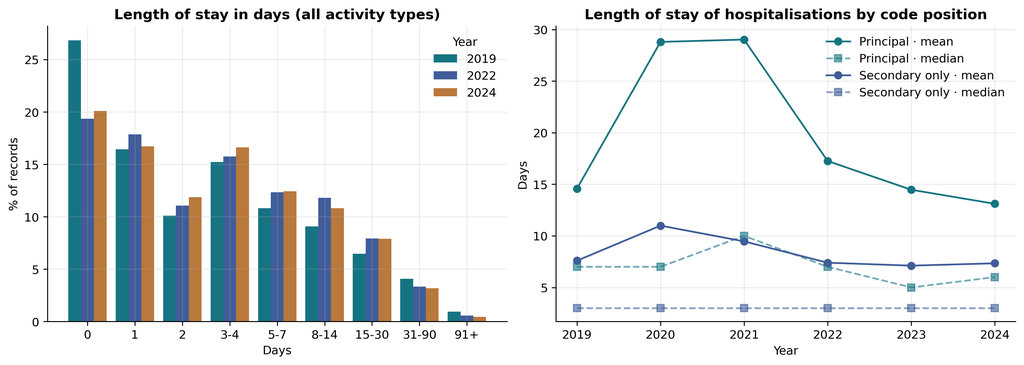

Figure 6: Distribution of length of stay (days between admission and discharge) of records with an ASD code, by year, and mean length of stay by code position.

```python
los_bins = main_features.loc[main_features.variable == "los_bin"].groupby(["year", "value"]).records.sum().unstack("year").reindex(LOS_BINS).fillna(0)
los_pct = los_bins / los_bins.sum()
fig, axes = plt.subplots(1, 2, figsize=(12, 4.2), layout="constrained")
for i, year in enumerate([first_year, 2022, last_year]):
    axes[0].bar(np.arange(len(LOS_BINS)) + (i - 1) * .27, 100 * los_pct[year], width=.27, color=COLORS[i], label=str(year))
axes[0].set(title="Length of stay in days (all activity types)", xlabel="Days", ylabel="% of records", xticks=range(len(LOS_BINS)), xticklabels=LOS_BINS)
axes[0].legend(title="Year")
for role, color in zip(["principal", "solo_secundario"], COLORS):
    frame = hosp_roles.loc[hosp_roles.role == role].groupby("year").apply(
        lambda g: pd.Series({"media": (g["mean"] * g.n).sum() / g.n.sum(), "mediana": g.loc[g.n.idxmax(), "median"]}), include_groups=False).reset_index()
    axes[1].plot(frame.year, frame.media, "o-", color=color, label=f"{POSITION_LABELS[role]} · mean")
    axes[1].plot(frame.year, frame.mediana, "s--", color=color, alpha=.6, label=f"{POSITION_LABELS[role]} · median")
axes[1].set(title="Length of stay of hospitalisations by code position", xlabel="Year", ylabel="Days", xticks=YEARS)
axes[1].legend()
plt.show()
```

Hospitalisations with autism as the principal diagnosis are longer and more dispersed, consistent with psychiatric admissions or behavioural assessment; hospitalisations with the code in a secondary position follow the distribution of the principal cause. The mean is sensitive to isolated prolonged stays; the median and the 90th percentile describe the typical experience better.

### Severity, mortality risk and GRD relative weight

**Show the code that produced this**

```python
feature_table("IR_29301_SEVERIDAD", "Severity level assigned by the IR-GRD grouper (0: not applicable or not grouped; 1 to 3: lowest to highest)")
feature_table("IR_29301_MORTALIDAD", "Mortality risk level assigned by the IR-GRD grouper (0: not applicable; 1 to 3)")
weight = grd_weight.loc[grd_weight.definition == DEFINITION].copy()
weight["Position"] = weight.role.map(POSITION_LABELS)
show_table(weight[["year", "Position", "n", "mean", "median", "q25", "q75"]].rename(columns={
    "year": "Year", "n": "Records with a weight", "mean": "Mean weight", "median": "Median", "q25": "Q1", "q75": "Q3"}),
    "GRD relative weight of the episodes by code position", {"Mean weight": 3, "Median": 3, "Q1": 3, "Q3": 3})
```

Severity level assigned by the IR-GRD grouper (0: not applicable or not grouped; 1 to 3: lowest to highest)

| Category | 2019 | 2022 | 2024 | Total 2019–2024 | % 2019 | % 2022 | % 2024 | % 2019–2024 |
| --- | --- | --- | --- | --- | --- | --- | --- | --- |
| 1 | 1,123 | 1,782 | 3,649 | 11,248 | 48.3 | 46.3 | 41.9 | 44.5 |
| 2 | 523 | 945 | 2,168 | 6,240 | 22.5 | 24.5 | 24.9 | 24.7 |
| 3 | 347 | 776 | 1,787 | 5,079 | 14.9 | 20.2 | 20.5 | 20.1 |
| 0 | 331 | 348 | 1,112 | 2,683 | 14.2 | 9.0 | 12.8 | 10.6 |

Mortality risk level assigned by the IR-GRD grouper (0: not applicable; 1 to 3)

| Category | 2019 | 2022 | 2024 | Total 2019–2024 | % 2019 | % 2022 | % 2024 | % 2019–2024 |
| --- | --- | --- | --- | --- | --- | --- | --- | --- |
| 1 | 1,455 | 2,400 | 5,143 | 15,397 | 62.6 | 62.3 | 59.0 | 61.0 |
| 2 | 364 | 681 | 1,326 | 4,216 | 15.7 | 17.7 | 15.2 | 16.7 |
| 3 | 174 | 422 | 1,135 | 2,954 | 7.5 | 11.0 | 13.0 | 11.7 |
| 0 | 331 | 348 | 1,112 | 2,683 | 14.2 | 9.0 | 12.8 | 10.6 |

GRD relative weight of the episodes by code position

| Year | Position | Records with a weight | Mean weight | Median | Q1 | Q3 |
| --- | --- | --- | --- | --- | --- | --- |
| 2019 | Principal | 221 | 0.588 | 0.582 | 0.582 | 0.651 |
| 2019 | Principal and secondary | 6 | 0.617 | 0.617 | 0.582 | 0.651 |
| 2019 | Secondary only | 2,097 | 0.872 | 0.574 | 0.446 | 0.917 |
| 2020 | Principal | 152 | 0.660 | 0.582 | 0.582 | 0.651 |
| 2020 | Principal and secondary | 5 | 0.582 | 0.582 | 0.582 | 0.582 |
| 2020 | Secondary only | 1,441 | 0.964 | 0.651 | 0.509 | 1.040 |
| 2021 | Principal | 183 | 0.624 | 0.582 | 0.582 | 0.651 |
| 2021 | Principal and secondary | 3 | 0.668 | 0.582 | 0.582 | 0.712 |
| 2021 | Secondary only | 2,169 | 0.981 | 0.632 | 0.465 | 1.006 |
| 2022 | Principal | 286 | 0.651 | 0.582 | 0.582 | 0.651 |
| 2022 | Principal and secondary | 8 | 0.608 | 0.582 | 0.582 | 0.651 |
| 2022 | Secondary only | 3,557 | 0.893 | 0.614 | 0.464 | 0.963 |
| 2023 | Principal | 351 | 0.620 | 0.582 | 0.582 | 0.651 |
| 2023 | Principal and secondary | 7 | 0.629 | 0.582 | 0.582 | 0.616 |
| 2023 | Secondary only | 6,048 | 0.867 | 0.610 | 0.446 | 0.963 |
| 2024 | Principal | 373 | 0.625 | 0.582 | 0.582 | 0.651 |
| 2024 | Principal and secondary | 15 | 0.649 | 0.651 | 0.582 | 0.651 |
| 2024 | Secondary only | 8,328 | 0.824 | 0.583 | 0.430 | 0.917 |

### Hospitals

**Show the code that produced this**

```python
hosp_main = hospitals.loc[hospitals.definition == DEFINITION].groupby(["COD_HOSPITAL", "hospital"], dropna=False).agg(
    records=("records", "sum")).reset_index().sort_values("records", ascending=False)
hosp_year = hospitals.loc[hospitals.definition == DEFINITION].groupby(["COD_HOSPITAL", "year"]).records.sum().unstack("year").fillna(0)
hosp_main["% of total"] = 100 * hosp_main.records / hosp_main.records.sum()
hosp_main["Cumulative %"] = hosp_main["% of total"].cumsum()
top = hosp_main.head(20).merge(hosp_year[[first_year, last_year]].reset_index(), on="COD_HOSPITAL", how="left")
top["hospital"] = top.hospital.fillna("No name in catalogue")
show_table(top[["COD_HOSPITAL", "hospital", "records", first_year, last_year, "% of total", "Cumulative %"]].rename(columns={
    "COD_HOSPITAL": "Code", "hospital": "Facility", "records": "Records 2019–2024"}),
    "Twenty facilities with the most records with an ASD code (any position)", {"% of total": 1, "Cumulative %": 1})
n_hosp = hospitals.loc[hospitals.definition == DEFINITION].groupby("year").COD_HOSPITAL.nunique()
note(f"Facilities with at least one ASD record per year: {', '.join(f'{y}: {n}' for y, n in n_hosp.items())}. "
     f"The top ten account for {number(hosp_main['Cumulative %'].iloc[9], 1)}% of the records.")
```

Twenty facilities with the most records with an ASD code (any position)

| Code | Facility | Records 2019–2024 | 2019 | 2024 | % of total | Cumulative % |
| --- | --- | --- | --- | --- | --- | --- |
| 114101 | Complejo Hospitalario Dr. Sótero del Río (Santiago, Puente Alto) | 1,610 | 106 | 513 | 6.4 | 6.4 |
| 113130 | Hospital Dr. Exequiel González Cortés (Santiago, San Miguel) | 1,391 | 59 | 518 | 5.5 | 11.9 |
| 118100 | Hospital Clínico Regional Dr. Guillermo Grant Benavente (Concepción) | 1,195 | 132 | 344 | 4.7 | 16.6 |
| 103100 | Hospital Dr. Leonardo Guzmán (Antofagasta) | 1,070 | 89 | 333 | 4.2 | 20.9 |
| 109101 | Hospital Clínico de Niños Dr. Roberto del Río (Santiago, Independencia) | 1,064 | 89 | 330 | 4.2 | 25.1 |
| 111100 | Hospital Clínico San Borja-Arriarán (Santiago, Santiago) | 1,012 | 177 | 337 | 4.0 | 29.1 |
| 117101 | Hospital Clínico Herminda Martín (Chillán) | 1,001 | 98 | 281 | 4.0 | 33.0 |
| 107100 | Hospital Dr. Gustavo Fricke (Viña del Mar) | 981 | 67 | 369 | 3.9 | 36.9 |
| 121109 | Hospital Dr. Hernán Henríquez Aravena (Temuco) | 851 | 72 | 290 | 3.4 | 40.3 |
| 112102 | Hospital de Niños Dr. Luis Calvo Mackenna (Santiago, Providencia) | 783 | 86 | 258 | 3.1 | 43.4 |
| 120101 | Complejo Asistencial Dr. Víctor Ríos Ruiz (Los Ángeles) | 780 | 147 | 209 | 3.1 | 46.5 |
| 119100 | Hospital Las Higueras (Talcahuano) | 769 | 69 | 257 | 3.0 | 49.5 |
| 106100 | Hospital Carlos Van Buren (Valparaíso) | 685 | 79 | 275 | 2.7 | 52.2 |
| 115100 | Hospital Regional de Rancagua | 578 | 30 | 193 | 2.3 | 54.5 |
| 102100 | Hospital Dr. Ernesto Torres Galdames (Iquique) | 568 | 62 | 211 | 2.2 | 56.8 |
| 105101 | Hospital San Pablo (Coquimbo) | 557 | 48 | 212 | 2.2 | 59.0 |
| 101100 | Hospital Dr. Juan Noé Crevanni (Arica) | 551 | 38 | 168 | 2.2 | 61.2 |
| 105100 | Hospital San Juan de Dios (La Serena) | 542 | 30 | 206 | 2.1 | 63.3 |
| 124105 | Hospital de Puerto Montt | 535 | 54 | 182 | 2.1 | 65.4 |
| 116105 | Hospital Dr. César Garavagno Burotto (Talca) | 524 | 51 | 171 | 2.1 | 67.5 |

Facilities with at least one ASD record per year: 2019: 65, 2020: 65, 2021: 62, 2022: 64, 2023: 68, 2024: 72. The top ten account for 43.4% of the records.

The concentration in paediatric hospitals and hospital complexes of the Metropolitan Region and Biobío reflects their volume and regional referral; it does not indicate differences in risk. Counts by facility are records, not persons.

## A6. Readmission and episode multiplicity

**Show the code that produced this**

```python
re = readmissions.loc[readmissions.definition == DEFINITION].copy()
re["% readmitted"] = 100 * re.readmitted / re.eligible.replace(0, np.nan)
limits = [stats.beta.interval(.95, r + .5, e - r + .5) if e else (np.nan, np.nan) for r, e in zip(re.readmitted, re.eligible)]
re["95% CI"] = [ci(100 * lo, 100 * hi, 1) for lo, hi in limits]
table = re.sort_values(["horizon_days", "year"])[["era", "year", "horizon_days", "discharges", "eligible", "readmitted", "% readmitted", "95% CI"]].rename(columns={
    "era": "Period", "year": "Year", "horizon_days": "Horizon (days)", "discharges": "Discharges with identifier and dates", "eligible": "With horizon available",
    "readmitted": "With a new admission with an ASD code"})
show_table(table, "Readmission with an ASD code within 30 and 90 days of discharge, same identifier and period", {"% readmitted": 1})
```

Readmission with an ASD code within 30 and 90 days of discharge, same identifier and period

| Period | Year | Horizon (days) | Discharges with identifier and dates | With horizon available | With a new admission with an ASD code | % readmitted | 95% CI |
| --- | --- | --- | --- | --- | --- | --- | --- |
| 2019-2020 | 2019 | 30 | 2,320 | 2,320 | 247 | 10.6 | 9.4 to 12.0 |
| 2019-2020 | 2020 | 30 | 1,598 | 1,448 | 175 | 12.1 | 10.5 to 13.8 |
| 2021-2024 | 2021 | 30 | 2,355 | 2,355 | 248 | 10.5 | 9.3 to 11.8 |
| 2021-2024 | 2022 | 30 | 3,848 | 3,848 | 380 | 9.9 | 9.0 to 10.8 |
| 2021-2024 | 2023 | 30 | 6,404 | 6,404 | 731 | 11.4 | 10.7 to 12.2 |
| 2021-2024 | 2024 | 30 | 8,712 | 7,945 | 825 | 10.4 | 9.7 to 11.1 |
| 2019-2020 | 2019 | 90 | 2,320 | 2,320 | 348 | 15.0 | 13.6 to 16.5 |
| 2019-2020 | 2020 | 90 | 1,598 | 1,161 | 199 | 17.1 | 15.1 to 19.4 |
| 2021-2024 | 2021 | 90 | 2,355 | 2,355 | 378 | 16.1 | 14.6 to 17.6 |
| 2021-2024 | 2022 | 90 | 3,848 | 3,848 | 566 | 14.7 | 13.6 to 15.9 |
| 2021-2024 | 2023 | 90 | 6,404 | 6,404 | 1,080 | 16.9 | 16.0 to 17.8 |
| 2021-2024 | 2024 | 90 | 8,712 | 6,273 | 993 | 15.8 | 14.9 to 16.7 |

**Show the code that produced this**

```python
mult = multiplicity.loc[multiplicity.definition == DEFINITION].copy()
mult["% of persons"] = 100 * mult.persons / mult.groupby("era").persons.transform("sum")
mult["% of records"] = 100 * mult.records / mult.groupby("era").records.transform("sum")
show_table(mult.sort_values(["era", "episodes"])[["era", "episodes", "persons", "% of persons", "records", "% of records"]].rename(columns={
    "era": "Period", "episodes": "Episodes with an ASD code per person", "persons": "Persons", "records": "Records"}),
    "Distribution of the number of episodes with an ASD code per identifier within each period", {"% of persons": 1, "% of records": 1})
```

Distribution of the number of episodes with an ASD code per identifier within each period

| Period | Episodes with an ASD code per person | Persons | % of persons | Records | % of records |
| --- | --- | --- | --- | --- | --- |
| 2019-2020 | 1 | 2,621 | 85.0 | 2,621 | 66.9 |
| 2019-2020 | 2 | 314 | 10.2 | 628 | 16.0 |
| 2019-2020 | 3 | 78 | 2.5 | 234 | 6.0 |
| 2019-2020 | 4-5 | 47 | 1.5 | 199 | 5.1 |
| 2019-2020 | 6+ | 25 | 0.8 | 236 | 6.0 |
| 2021-2024 | 1 | 12,641 | 80.9 | 12,641 | 59.3 |
| 2021-2024 | 2 | 1,956 | 12.5 | 3,912 | 18.3 |
| 2021-2024 | 3 | 541 | 3.5 | 1,623 | 7.6 |
| 2021-2024 | 4-5 | 300 | 1.9 | 1,296 | 6.1 |
| 2021-2024 | 6+ | 189 | 1.2 | 1,850 | 8.7 |

Readmission is measured only with episodes that again carry the autism code, so it underestimates all-cause readmission. Most persons have a single episode in the period; a minority accumulate several episodes and account for a disproportionate share of the records.

## A7. Co-diagnoses and principal reason for hospitalisation

**Show the code that produced this**

```python
co = codiagnoses.loc[codiagnoses.definition == DEFINITION].copy()
co_any = co.groupby("code3").records.sum().sort_values(ascending=False)
records_all = quality.records_kept.sum()
n_main = positions_year.loc[positions_year.definition == DEFINITION].records.sum()
top = co_any.head(25).reset_index()
top["Description"] = top.code3.map(icd_label)
top["Chapter"] = top.code3.map(icd_chapter)
top["% of ASD records"] = 100 * top.records / n_main
co_year = co.groupby(["code3", "year"]).records.sum().unstack("year").fillna(0)
n_year = positions_year.loc[positions_year.definition == DEFINITION].groupby("source_year").records.sum()
for year in [first_year, last_year]:
    top[f"% {year}"] = 100 * co_year[year].reindex(top.code3).values / n_year[year]
show_table(top[["code3", "Description", "Chapter", "records", "% of ASD records", f"% {first_year}", f"% {last_year}"]].rename(columns={
    "code3": "ICD-10", "records": "Records with the code"}),
    "Twenty-five most frequent ICD-10 categories in records with an ASD code, any position · 2019–2024", {"% of ASD records": 1, f"% {first_year}": 1, f"% {last_year}": 1})
```

Twenty-five most frequent ICD-10 categories in records with an ASD code, any position · 2019–2024

| ICD-10 | Description | Chapter | Records with the code | % of ASD records | % 2019 | % 2024 |
| --- | --- | --- | --- | --- | --- | --- |
| Z92 | Personal history of medical treatment | Factors influencing health status | 4,196 | 16.6 | 12.5 | 19.2 |
| G40 | Epilepsy | Nervous system | 3,491 | 13.8 | 19.2 | 11.2 |
| E66 | Obesity | Endocrine, nutritional and metabolic | 2,894 | 11.5 | 7.5 | 12.3 |
| J45 | Asthma | Respiratory system | 2,743 | 10.9 | 8.6 | 13.2 |
| F32 | Depressive episode | Mental and behavioural disorders | 1,958 | 7.8 | 2.6 | 10.3 |
| J96 | Respiratory failure | Respiratory system | 1,920 | 7.6 | 4.6 | 9.0 |
| Z91 | Personal history of risk factors | Factors influencing health status | 1,880 | 7.4 | 3.3 | 10.0 |
| Z63 | Problems related to primary support group | Factors influencing health status | 1,544 | 6.1 | 4.1 | 7.5 |
| Z87 | Personal history of other diseases | Factors influencing health status | 1,517 | 6.0 | 7.0 | 6.7 |
| K59 | Other functional intestinal disorders | Digestive system | 1,469 | 5.8 | 4.8 | 5.5 |
| R45 | Symptoms involving emotional state | Symptoms and signs, not elsewhere classified | 1,420 | 5.6 | 3.6 | 7.0 |
| Z88 | Personal history of allergy | Factors influencing health status | 1,340 | 5.3 | 4.1 | 5.9 |
| E87 | Other fluid and electrolyte disorders | Endocrine, nutritional and metabolic | 1,245 | 4.9 | 3.1 | 4.6 |
| F90 | Hyperkinetic disorders | Mental and behavioural disorders | 1,199 | 4.8 | 2.5 | 7.4 |
| F60 | Specific personality disorders | Mental and behavioural disorders | 1,121 | 4.4 | 1.3 | 6.8 |
| N47 | Redundant prepuce, phimosis and paraphimosis | Genitourinary system | 1,110 | 4.4 | 3.7 | 5.2 |
| J12 | Viral pneumonia | Respiratory system | 1,062 | 4.2 | 3.0 | 4.6 |
| R62 | Lack of expected development | Symptoms and signs, not elsewhere classified | 1,028 | 4.1 | 3.2 | 3.4 |
| J30 |  | Respiratory system | 993 | 3.9 | 2.2 | 5.3 |
| E03 | Other hypothyroidism | Endocrine, nutritional and metabolic | 985 | 3.9 | 5.5 | 4.0 |
| F41 | Other anxiety disorders | Mental and behavioural disorders | 975 | 3.9 | 0.5 | 5.6 |
| K35 | Acute appendicitis | Digestive system | 975 | 3.9 | 3.2 | 3.8 |
| J35 | Chronic diseases of tonsils and adenoids | Respiratory system | 942 | 3.7 | 3.2 | 4.5 |
| F91 | Conduct disorders | Mental and behavioural disorders | 821 | 3.3 | 2.7 | 3.2 |
| F43 | Reaction to severe stress and adjustment disorders | Mental and behavioural disorders | 808 | 3.2 | 1.6 | 4.8 |

**Show the code that produced this**

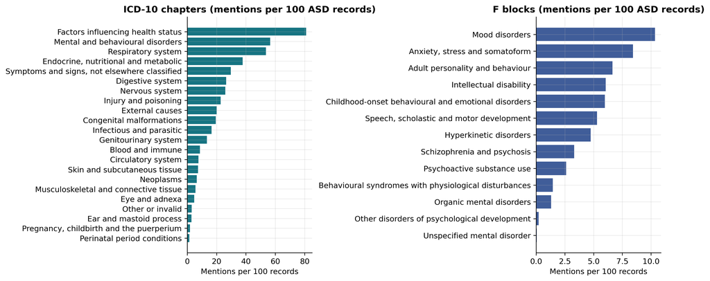

Figure 7: ICD-10 chapters of the co-diagnoses and mental health (F) blocks present in records with an ASD code, as a percentage of records; a record counts once per category.

```python
co["chapter"] = co.code3.map(icd_chapter)
chapters = co.groupby("chapter").records.sum().sort_values()
co_f = co.loc[co.code3.str.startswith("F")].copy()
co_f["block"] = co_f.code3.map(mental_block)
blocks = co_f.groupby("block").records.sum().sort_values()
fig, axes = plt.subplots(1, 2, figsize=(12, 5), layout="constrained")
axes[0].barh(chapters.index, 100 * chapters.values / n_main, color=COLORS[0])
axes[0].set(title="ICD-10 chapters (mentions per 100 ASD records)", xlabel="Mentions per 100 records")
axes[1].barh(blocks.index, 100 * blocks.values / n_main, color=COLORS[1])
axes[1].set(title="F blocks (mentions per 100 ASD records)", xlabel="Mentions per 100 records")
plt.show()
```

Mentions per 100 records can exceed 100 because a record may carry several categories from the same chapter. Epilepsy (G40), hyperkinetic disorders (F90), intellectual disability (F70–F79), mood and anxiety disorders, obesity, asthma and the Z codes for personal history are the most frequent accompanying conditions, in line with the literature on comorbidity. Their co-occurrence within an episode establishes neither sequence nor causality.

### Principal diagnosis when autism is secondary

**Show the code that produced this**

```python
principal = co.loc[(co.code_position == "principal") & (co.role == "solo_secundario")].groupby("code3").records.sum().sort_values(ascending=False)
n_secondary = positions_year.loc[(positions_year.definition == DEFINITION) & (positions_year.role == "solo_secundario")].records.sum()
top = principal.head(25).reset_index()
top["Description"] = top.code3.map(icd_label)
top["Chapter"] = top.code3.map(icd_chapter)
top["% of episodes with secondary ASD"] = 100 * top.records / n_secondary
show_table(top.rename(columns={"code3": "Principal ICD-10", "records": "Records"}),
           "Most frequent principal diagnosis of hospitalisations in which the ASD code occupies only secondary positions · 2019–2024", {"% of episodes with secondary ASD": 1})
chap = co.loc[(co.code_position == "principal") & (co.role == "solo_secundario")].assign(chapter=lambda d: d.code3.map(icd_chapter)).groupby("chapter").records.sum().sort_values(ascending=False).reset_index()
chap["%"] = 100 * chap.records / n_secondary
show_table(chap.rename(columns={"chapter": "ICD-10 chapter of the principal diagnosis", "records": "Records"}), "Chapter of the principal diagnosis when ASD is secondary", {"%": 1})
```

Most frequent principal diagnosis of hospitalisations in which the ASD code occupies only secondary positions · 2019–2024

| Principal ICD-10 | Records | Description | Chapter | % of episodes with secondary ASD |
| --- | --- | --- | --- | --- |
| G40 | 1,289 | Epilepsy | Nervous system | 5.5 |
| K35 | 960 | Acute appendicitis | Digestive system | 4.1 |
| N47 | 890 | Redundant prepuce, phimosis and paraphimosis | Genitourinary system | 3.8 |
| F32 | 786 | Depressive episode | Mental and behavioural disorders | 3.3 |
| J12 | 767 | Viral pneumonia | Respiratory system | 3.2 |
| Z51 | 706 | Other medical care | Factors influencing health status | 3.0 |
| J35 | 705 | Chronic diseases of tonsils and adenoids | Respiratory system | 3.0 |
| K02 | 529 | Dental caries | Digestive system | 2.2 |
| J46 | 471 | Status asthmaticus | Respiratory system | 2.0 |
| T43 | 427 | Poisoning by psychotropic drugs | Injury and poisoning | 1.8 |
| J20 | 376 | Acute bronchitis | Respiratory system | 1.6 |
| A09 | 339 | Diarrhoea and gastroenteritis of presumed infectious origin | Infectious and parasitic | 1.4 |
| Q53 | 333 |  | Congenital malformations | 1.4 |
| J15 | 302 | Bacterial pneumonia | Respiratory system | 1.3 |
| R56 | 279 | Convulsions | Symptoms and signs, not elsewhere classified | 1.2 |
| F60 | 272 | Specific personality disorders | Mental and behavioural disorders | 1.2 |
| A08 | 261 | Viral intestinal infections | Infectious and parasitic | 1.1 |
| F91 | 231 | Conduct disorders | Mental and behavioural disorders | 1.0 |
| F43 | 218 | Reaction to severe stress and adjustment disorders | Mental and behavioural disorders | 0.9 |
| Z13 | 218 |  | Factors influencing health status | 0.9 |
| S52 | 212 | Fracture of forearm | Injury and poisoning | 0.9 |
| J18 | 210 | Pneumonia, organism unspecified | Respiratory system | 0.9 |
| K80 | 192 | Cholelithiasis | Digestive system | 0.8 |
| E10 | 190 | Type 1 diabetes mellitus | Endocrine, nutritional and metabolic | 0.8 |
| F41 | 189 | Other anxiety disorders | Mental and behavioural disorders | 0.8 |

Chapter of the principal diagnosis when ASD is secondary

| ICD-10 chapter of the principal diagnosis | Records | % |
| --- | --- | --- |
| Respiratory system | 3,668 | 15.5 |
| Injury and poisoning | 3,096 | 13.1 |
| Digestive system | 3,072 | 13.0 |
| Mental and behavioural disorders | 2,975 | 12.6 |
| Nervous system | 1,850 | 7.8 |
| Genitourinary system | 1,519 | 6.4 |
| Factors influencing health status | 1,399 | 5.9 |
| Congenital malformations | 1,003 | 4.2 |
| Infectious and parasitic | 951 | 4.0 |
| Symptoms and signs, not elsewhere classified | 758 | 3.2 |
| Neoplasms | 625 | 2.6 |
| Musculoskeletal and connective tissue | 513 | 2.2 |
| Endocrine, nutritional and metabolic | 473 | 2.0 |
| Skin and subcutaneous tissue | 387 | 1.6 |
| Blood and immune | 331 | 1.4 |
| Circulatory system | 269 | 1.1 |
| Eye and adnexa | 247 | 1.0 |
| Ear and mastoid process | 187 | 0.8 |
| Pregnancy, childbirth and the puerperium | 154 | 0.7 |
| Other or invalid | 150 | 0.6 |
| Perinatal period conditions | 8 | 0.0 |

The principal reasons include dental caries and dental disease (dental care under general anaesthesia), epilepsy, respiratory infections, appendicitis, phimosis and tonsillar disease, as well as psychiatric causes (depressive episodes, conduct disorders) and poisonings. This profile describes why persons with an autism code reach hospital, not the frequency of those conditions in the autistic population.

## A8. Place: regions and communes of residence

### Regions

**Show the code that produced this**

```python
reg = regional.loc[(regional.unit == "records") & (regional.sex == "TOTAL")].copy()
pooled = reg.loc[reg.period == "2019-2024"].set_index("cut_region")
last = reg.loc[reg.period == str(last_year)].set_index("cut_region")
first = reg.loc[reg.period == str(first_year)].set_index("cut_region")
persons_reg = regional.loc[(regional.unit == "persons") & (regional.sex == "TOTAL") & (regional.period == "2021-2024")].set_index("cut_region")
sexes = regional.loc[(regional.unit == "records") & (regional.period == "2019-2024")].pivot(index="cut_region", columns="sex", values="asr")
table = pd.DataFrame({
    "Region": [REGION_NAMES[r] for r in REGION_ORDER],
    "Records 2019–2024": pooled["count"].reindex(REGION_ORDER).values,
    "Person-years 2019–2024": pooled.population.reindex(REGION_ORDER).values,
    "ASR 2019–2024": pooled.asr.reindex(REGION_ORDER).values,
    "95% CI": [ci(lo, hi) for lo, hi in zip(pooled.asr_lo.reindex(REGION_ORDER), pooled.asr_hi.reindex(REGION_ORDER))],
    f"ASR {first_year}": first.asr.reindex(REGION_ORDER).values,
    f"ASR {last_year}": last.asr.reindex(REGION_ORDER).values,
    "M:F ratio 2019–2024": (sexes["HOMBRE"] / sexes["MUJER"]).reindex(REGION_ORDER).values,
    "Persons 2021–2024 per 100 000": persons_reg.asr.reindex(REGION_ORDER).values,
})
national = records_total.loc[[first_year, last_year], "asr"]
table = pd.concat([table, pd.DataFrame([{"Region": "Chile", "Records 2019–2024": records_total["count"].sum(), "Person-years 2019–2024": records_total.population.sum(),
                                          f"ASR {first_year}": national.loc[first_year], f"ASR {last_year}": national.loc[last_year]}])], ignore_index=True)
show_table(table, "Age-standardised rates of records with an ASD code by region of residence, per 100 000 person-years, and hospitalised persons 2021–2024 per 100 000 population",
           {"ASR 2019–2024": 1, f"ASR {first_year}": 1, f"ASR {last_year}": 1, "M:F ratio 2019–2024": 2, "Persons 2021–2024 per 100 000": 1})
```

Age-standardised rates of records with an ASD code by region of residence, per 100 000 person-years, and hospitalised persons 2021–2024 per 100 000 population

| Region | Records 2019–2024 | Person-years 2019–2024 | ASR 2019–2024 | 95% CI | ASR 2019 | ASR 2024 | M:F ratio 2019–2024 | Persons 2021–2024 per 100 000 |
| --- | --- | --- | --- | --- | --- | --- | --- | --- |
| Arica y Parinacota | 592 | 1,533,829 | 47.0 | 43.3 to 51.0 | 20.5 | 86.9 | 2.39 | 47.4 |
| Tarapacá | 596 | 2,347,416 | 29.0 | 26.7 to 31.5 | 20.8 | 65.0 | 1.73 | 29.8 |
| Antofagasta | 1,453 | 4,206,174 | 42.6 | 40.4 to 44.9 | 19.5 | 85.2 | 1.92 | 45.7 |
| Atacama | 356 | 1,899,797 | 22.1 | 19.9 to 24.6 | 13.1 | 41.6 | 2.79 | 22.1 |
| Coquimbo | 1,469 | 5,113,040 | 36.8 | 34.9 to 38.7 | 15.8 | 82.7 | 3.17 | 39.3 |
| Valparaíso | 2,445 | 11,907,078 | 28.2 | 27.1 to 29.3 | 15.8 | 64.4 | 2.20 | 29.6 |
| Metropolitan | 8,061 | 49,382,233 | 22.3 | 21.8 to 22.8 | 11.7 | 45.6 | 2.48 | 23.2 |
| O'Higgins | 905 | 6,023,729 | 20.1 | 18.8 to 21.5 | 11.5 | 40.9 | 2.64 | 20.9 |
| Maule | 1,252 | 6,881,564 | 24.2 | 22.9 to 25.6 | 10.1 | 57.1 | 3.14 | 26.7 |
| Ñuble | 1,249 | 3,092,226 | 55.0 | 52.0 to 58.2 | 31.4 | 100.0 | 1.81 | 60.2 |
| Biobío | 3,229 | 10,032,954 | 43.1 | 41.6 to 44.6 | 29.1 | 88.5 | 2.44 | 44.0 |
| La Araucanía | 1,477 | 6,126,250 | 30.9 | 29.4 to 32.6 | 13.2 | 72.6 | 2.34 | 33.6 |
| Los Ríos | 402 | 2,450,616 | 22.3 | 20.1 to 24.6 | 17.5 | 38.2 | 3.24 | 19.7 |
| Los Lagos | 1,179 | 5,395,317 | 29.0 | 27.3 to 30.7 | 20.4 | 58.7 | 2.50 | 30.5 |
| Aysén | 195 | 646,605 | 37.4 | 32.2 to 43.1 | 18.1 | 89.6 | 3.03 | 37.2 |
| Magallanes | 376 | 1,080,890 | 47.3 | 42.6 to 52.4 | 47.2 | 64.6 | 3.62 | 42.2 |
| Chile | 25,238 | 118,119,718 | — | — | 15.8 | 59.2 | — | — |

**Show the code that produced this**

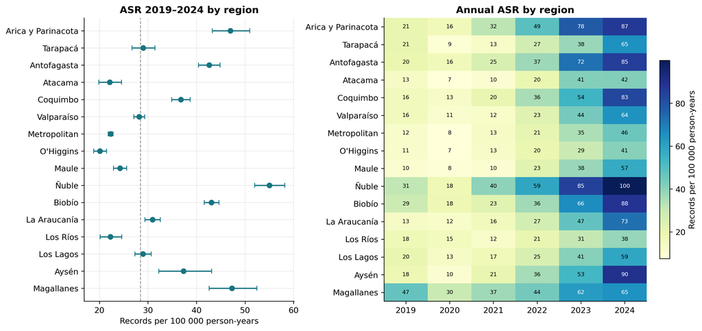

Figure 8: Age-standardised rate of records with an ASD code by region of residence (2019–2024 pooled, with 95% interval) and annual evolution by region (ASR, colour scale).

```python
fig, axes = plt.subplots(1, 2, figsize=(12, 5.6), layout="constrained", gridspec_kw={"width_ratios": [1, 1.25]})
ordered = pooled.reindex(REGION_ORDER)
y = np.arange(len(REGION_ORDER))
axes[0].errorbar(ordered.asr, y, xerr=[ordered.asr - ordered.asr_lo, ordered.asr_hi - ordered.asr], fmt="o", color=COLORS[0], capsize=3)
pooled_national = direct_standardization(age_specific.loc[(age_specific.definition == DEFINITION) & (age_specific.unit == "records") & (age_specific.sex == "TOTAL")])
axes[0].axvline(pooled_national["asr"], color="#999999", linestyle="--", linewidth=1)
axes[0].set_yticks(y)
axes[0].set_yticklabels([REGION_NAMES[r] for r in REGION_ORDER])
axes[0].invert_yaxis()
axes[0].set(title="ASR 2019–2024 by region", xlabel="Records per 100 000 person-years")
annual = reg.loc[reg.year.notna()].pivot(index="cut_region", columns="year", values="asr").reindex(REGION_ORDER)
image = axes[1].imshow(annual.values, cmap="YlGnBu", aspect="auto")
axes[1].set_yticks(range(len(REGION_ORDER)))
axes[1].set_yticklabels([REGION_NAMES[r] for r in REGION_ORDER])
axes[1].set_xticks(range(annual.shape[1]))
axes[1].set_xticklabels([str(int(c)) for c in annual.columns])
for i in range(annual.shape[0]):
    for j in range(annual.shape[1]):
        axes[1].text(j, i, number(annual.values[i, j], 0), ha="center", va="center", fontsize=7, color="black" if annual.values[i, j] < np.nanmax(annual.values) * .6 else "white")
axes[1].set(title="Annual ASR by region")
axes[1].grid(False)
fig.colorbar(image, ax=axes[1], shrink=.7, label="Records per 100 000 person-years")
plt.show()
```

**Show the code that produced this**

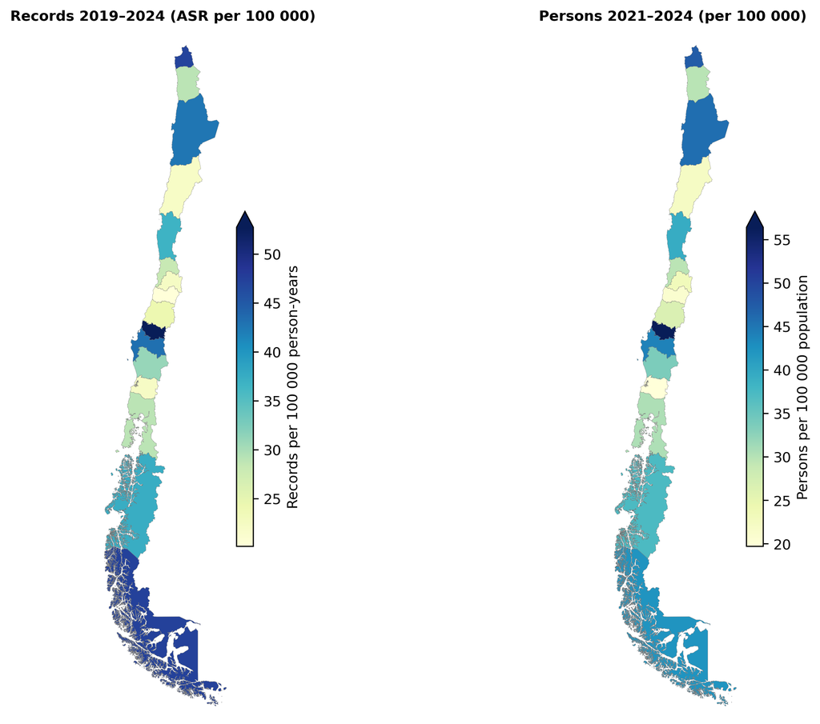

Figure 9: Regional maps: age-standardised rate of records with an ASD code 2019–2024 and of hospitalised persons 2021–2024, by region of residence.

```python
regions_shp = load_regions()
regions_shp = regions_shp.merge(pooled[["asr"]].rename(columns={"asr": "asr_records"}), left_on="cut_region", right_index=True, how="left")
regions_shp = regions_shp.merge(persons_reg[["asr"]].rename(columns={"asr": "asr_persons"}), left_on="cut_region", right_index=True, how="left")
fig, axes = plt.subplots(1, 2, figsize=(10, 7), layout="constrained")
choropleth(axes[0], regions_shp, "asr_records", "Records 2019–2024 (ASR per 100 000)", legend_label="Records per 100 000 person-years")
choropleth(axes[1], regions_shp, "asr_persons", "Persons 2021–2024 (per 100 000)", legend_label="Persons per 100 000 population")
plt.show()
```

The regions with the highest rates (Ñuble, Magallanes, Arica y Parinacota, Biobío, Antofagasta) combine hospitals with a large regional catchment and probably more exhaustive coding practices; the Metropolitan Region shows low rates despite having the largest absolute number of records. Regional differences describe hospital use and recording, not the distribution of autism.

### Communes

**Show the code that produced this**

```python
com = comunal.loc[(comunal.unit == "records") & comunal.continental].copy()
com["95% CI ASR"] = [ci(lo, hi) for lo, hi in zip(com.asr_lo, com.asr_hi)]
com["95% CI SHR"] = [ci(lo, hi, 2) for lo, hi in zip(com.sir_lo, com.sir_hi)]
stable = com.loc[com["count"] >= 20].sort_values("asr", ascending=False)
show_table(stable.head(25)[["comuna", "region_short", "count", "population", "crude", "asr", "95% CI ASR", "expected", "sir", "95% CI SHR", "sir_eb", "eb_weight"]].rename(columns={
    "comuna": "Commune", "region_short": "Region", "count": "Records", "population": "Person-years", "crude": "Crude rate", "asr": "ASR",
    "expected": "Expected", "sir": "SHR", "sir_eb": "Smoothed SHR", "eb_weight": "EB weight"}),
    "Twenty-five communes with the highest age-standardised rate of ASD records · 2019–2024, among continental communes with at least 20 records",
    {"Crude rate": 1, "ASR": 1, "Expected": 1, "SHR": 2, "Smoothed SHR": 2, "EB weight": 2})
note(f"Continental communes with records: {int((com['count'] > 0).sum())} of {len(com)}; with 20 or more records: {len(stable)}. "
     f"Median records per commune: {number(com['count'].median())}. The standardised hospitalisation ratio (SHR) compares the observed records with those expected from the national sex- and age-specific rates of the period.")
```

Twenty-five communes with the highest age-standardised rate of ASD records · 2019–2024, among continental communes with at least 20 records

| Commune | Region | Records | Person-years | Crude rate | ASR | 95% CI ASR | Expected | SHR | 95% CI SHR | Smoothed SHR | EB weight |
| --- | --- | --- | --- | --- | --- | --- | --- | --- | --- | --- | --- |
| San Carlos | Ñuble | 198 | 339,335 | 58.3 | 80.1 | 69.3 to 92.2 | 69.5 | 2.85 | 2.47 to 3.28 | 2.75 | 0.94 |
| Chillán | Ñuble | 674 | 1,204,065 | 56.0 | 74.4 | 68.9 to 80.3 | 255.8 | 2.64 | 2.44 to 2.84 | 2.61 | 0.98 |
| San Nicolás | Ñuble | 38 | 73,741 | 51.5 | 74.3 | 52.4 to 103.0 | 14.4 | 2.64 | 1.87 to 3.62 | 2.27 | 0.78 |
| Hualpén | Biobío | 264 | 585,392 | 45.1 | 63.3 | 55.9 to 71.5 | 119.2 | 2.21 | 1.96 to 2.50 | 2.17 | 0.97 |
| Talcahuano | Biobío | 425 | 949,569 | 44.8 | 61.6 | 55.8 to 67.8 | 192.9 | 2.20 | 2.00 to 2.42 | 2.18 | 0.98 |
| Frutillar | Los Lagos | 57 | 122,674 | 46.5 | 61.5 | 46.6 to 79.9 | 26.2 | 2.18 | 1.65 to 2.82 | 2.02 | 0.86 |
| Freirina | Atacama | 22 | 46,438 | 47.4 | 60.7 | 38.0 to 92.9 | 10.8 | 2.04 | 1.28 to 3.08 | 1.75 | 0.72 |
| Angol | La Araucanía | 151 | 338,025 | 44.7 | 58.9 | 49.9 to 69.2 | 74.5 | 2.03 | 1.72 to 2.38 | 1.97 | 0.95 |
| Lota | Biobío | 113 | 273,690 | 41.3 | 57.6 | 47.4 to 69.3 | 56.5 | 2.00 | 1.65 to 2.41 | 1.93 | 0.93 |
| Linares | Maule | 263 | 612,926 | 42.9 | 56.8 | 50.1 to 64.1 | 133.8 | 1.97 | 1.74 to 2.22 | 1.94 | 0.97 |
| Colbún | Maule | 57 | 137,440 | 41.5 | 54.8 | 41.5 to 71.2 | 29.5 | 1.93 | 1.46 to 2.51 | 1.82 | 0.88 |
| Victoria | La Araucanía | 85 | 212,998 | 39.9 | 54.6 | 43.6 to 67.6 | 44.4 | 1.91 | 1.53 to 2.37 | 1.84 | 0.91 |
| Punta Arenas | Magallanes | 340 | 860,088 | 39.5 | 53.2 | 47.6 to 59.2 | 176.0 | 1.93 | 1.73 to 2.15 | 1.91 | 0.98 |
| Tomé | Biobío | 133 | 353,315 | 37.6 | 52.9 | 44.3 to 62.8 | 71.0 | 1.87 | 1.57 to 2.22 | 1.83 | 0.95 |
| Coronel | Biobío | 315 | 762,024 | 41.3 | 51.6 | 46.1 to 57.7 | 174.1 | 1.81 | 1.62 to 2.02 | 1.79 | 0.98 |
| Penco | Biobío | 116 | 299,909 | 38.7 | 51.6 | 42.6 to 62.0 | 62.9 | 1.84 | 1.52 to 2.21 | 1.79 | 0.94 |
| Los Angeles | Biobío | 535 | 1,322,945 | 40.4 | 51.3 | 47.0 to 55.8 | 298.4 | 1.79 | 1.64 to 1.95 | 1.78 | 0.99 |
| Coquimbo | Coquimbo | 627 | 1,582,734 | 39.6 | 48.9 | 45.1 to 52.9 | 365.4 | 1.72 | 1.58 to 1.86 | 1.71 | 0.99 |
| Chépica | O'Higgins | 30 | 96,058 | 31.2 | 48.2 | 32.4 to 69.2 | 18.3 | 1.64 | 1.11 to 2.35 | 1.52 | 0.82 |
| Arica | Arica y Parinacota | 592 | 1,506,340 | 39.3 | 47.7 | 43.9 to 51.7 | 350.3 | 1.69 | 1.56 to 1.83 | 1.68 | 0.99 |
| Curanilahue | Biobío | 73 | 203,450 | 35.9 | 47.4 | 37.1 to 59.8 | 44.8 | 1.63 | 1.28 to 2.05 | 1.58 | 0.92 |
| Osorno | Los Lagos | 367 | 1,046,987 | 35.1 | 47.4 | 42.7 to 52.6 | 221.5 | 1.66 | 1.49 to 1.84 | 1.65 | 0.98 |
| Lautaro | La Araucanía | 96 | 247,047 | 38.9 | 46.8 | 37.9 to 57.2 | 56.7 | 1.69 | 1.37 to 2.07 | 1.65 | 0.93 |
| Laja | Biobío | 50 | 143,335 | 34.9 | 46.7 | 34.7 to 61.8 | 31.0 | 1.61 | 1.20 to 2.12 | 1.54 | 0.88 |
| Doñihue | O'Higgins | 49 | 138,320 | 35.4 | 46.0 | 34.0 to 61.0 | 30.7 | 1.60 | 1.18 to 2.11 | 1.53 | 0.88 |

Continental communes with records: 322 of 342; with 20 or more records: 170. Median records per commune: 19. The standardised hospitalisation ratio (SHR) compares the observed records with those expected from the national sex- and age-specific rates of the period.

**Show the code that produced this**

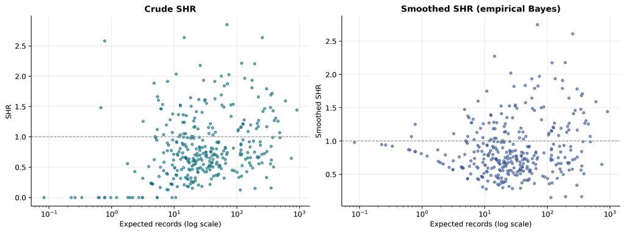

Figure 10: Relationship between commune population size and the crude and empirical Bayes smoothed standardised hospitalisation ratio (SHR); small communes show extreme ratios that smoothing shrinks towards the national ratio.

```python
fig, axes = plt.subplots(1, 2, figsize=(12, 4.4), layout="constrained")
axes[0].scatter(com.expected, com.sir, s=12, color=COLORS[0], alpha=.6)
axes[0].axhline(1, color="#999999", linestyle="--", linewidth=1)
axes[0].set(title="Crude SHR", xlabel="Expected records (log scale)", ylabel="SHR", xscale="log")
axes[1].scatter(com.expected, com.sir_eb, s=12, color=COLORS[1], alpha=.6)
axes[1].axhline(1, color="#999999", linestyle="--", linewidth=1)
axes[1].set(title="Smoothed SHR (empirical Bayes)", xlabel="Expected records (log scale)", ylabel="Smoothed SHR", xscale="log")
plt.show()
```

**Show the code that produced this**

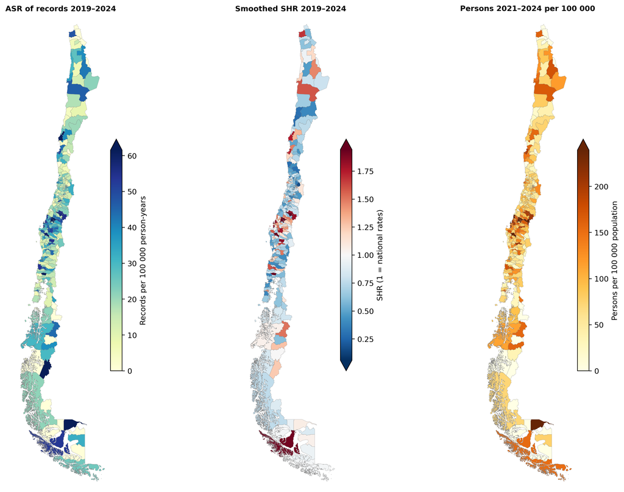

Figure 11: Commune maps (continental communes): age-standardised rate of ASD records 2019–2024, smoothed standardised hospitalisation ratio and hospitalised persons 2021–2024 per 100 000 population.

```python
comunas_shp = load_comunas()
map_records = comunal.loc[comunal.unit == "records", ["cut_comuna", "asr", "sir_eb"]].rename(columns={"asr": "asr_records", "sir_eb": "sir_eb_records"})
map_persons = comunal.loc[comunal.unit == "persons", ["cut_comuna", "asr"]].rename(columns={"asr": "asr_persons"})
comunas_map = comunas_shp.merge(map_records, on="cut_comuna", how="left").merge(map_persons, on="cut_comuna", how="left")
fig, axes = plt.subplots(1, 3, figsize=(13, 9), layout="constrained")
choropleth(axes[0], comunas_map, "asr_records", "ASR of records 2019–2024", legend_label="Records per 100 000 person-years")
choropleth(axes[1], comunas_map, "sir_eb_records", "Smoothed SHR 2019–2024", cmap="RdBu_r", legend_label="SHR (1 = national rates)", diverging_center=1.0)
choropleth(axes[2], comunas_map, "asr_persons", "Persons 2021–2024 per 100 000", cmap="YlOrBr", legend_label="Persons per 100 000 population")
plt.show()
```

Maps of crude commune rates are sensitive to population size; the smoothed ratio is the recommended reading. The projection stretches the south of the country; the communes of the far south and the non-continental ones are shown without additional cropping.

### Spatial autocorrelation: Moran’s I

**Show the code that produced this**

```python
mor = moran.copy()
mor["Unit"] = mor.unit.map({"records": "Records 2019–2024", "persons": "Persons 2021–2024"})
mor["Variable"] = mor.variable.map({"asr": "ASR", "sir": "Crude SHR", "sir_eb": "Smoothed SHR"})
show_table(mor[["Unit", "Variable", "n_comunas", "islands", "moran_i", "expected_i", "z_sim", "p_sim", "permutations"]].rename(columns={
    "n_comunas": "Communes", "islands": "Without neighbours", "moran_i": "Moran's I", "expected_i": "E[I]", "z_sim": "z (permutations)", "p_sim": "p (permutations)", "permutations": "Permutations"}),
    "Global Moran's I with queen contiguity, continental communes; permutation inference", {"Moran's I": 3, "E[I]": 4, "z (permutations)": 2, "p (permutations)": 3})
```

Global Moran's I with queen contiguity, continental communes; permutation inference

| Unit | Variable | Communes | Without neighbours | Moran's I | E[I] | z (permutations) | p (permutations) | Permutations |
| --- | --- | --- | --- | --- | --- | --- | --- | --- |
| Persons 2021–2024 | ASR | 342 | 4 | 0.297 | -0.0029 | 8.42 | 0.001 | 999 |
| Persons 2021–2024 | Crude SHR | 342 | 4 | 0.344 | -0.0029 | 9.51 | 0.001 | 999 |
| Persons 2021–2024 | Smoothed SHR | 342 | 4 | 0.409 | -0.0029 | 11.52 | 0.001 | 999 |
| Records 2019–2024 | ASR | 342 | 4 | 0.174 | -0.0029 | 5.35 | 0.001 | 999 |
| Records 2019–2024 | Crude SHR | 342 | 4 | 0.269 | -0.0029 | 7.56 | 0.001 | 999 |
| Records 2019–2024 | Smoothed SHR | 342 | 4 | 0.342 | -0.0029 | 9.93 | 0.001 | 999 |

**Show the code that produced this**

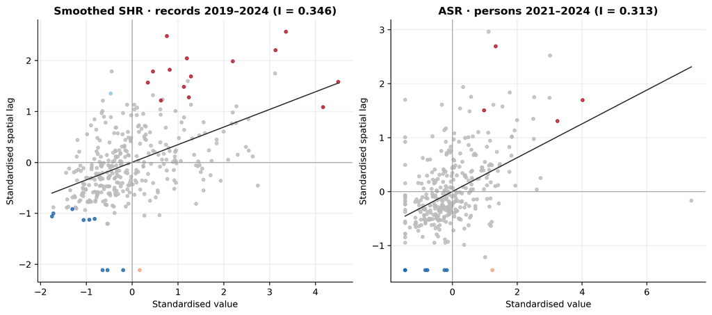

Figure 12: Moran scatter plots for the smoothed standardised hospitalisation ratio (records 2019–2024) and for the age-standardised rate of persons 2021–2024; standardised values against their spatial lag; the slope is Moran’s I.

```python
fig, axes = plt.subplots(1, 2, figsize=(11, 4.8), layout="constrained")
for ax, (unit, variable, title) in zip(axes, [("records", "sir_eb", "Smoothed SHR · records 2019–2024"), ("persons", "asr", "ASR · persons 2021–2024")]):
    frame = lisa.loc[(lisa.unit == unit) & (lisa.variable == variable)]
    z = (frame.value - frame.value.mean()) / frame.value.std(ddof=0)
    lag = (frame.spatial_lag - frame.value.mean()) / frame.value.std(ddof=0)
    ax.scatter(z, lag, s=12, color=frame.cluster_fdr.map({"Alto-Alto": "#b2182b", "Bajo-Bajo": "#2166ac", "Alto-Bajo": "#f4a582", "Bajo-Alto": "#92c5de"}).fillna("#bbbbbb"), alpha=.8)
    slope = np.polyfit(z, lag, 1)[0]
    xs = np.linspace(z.min(), z.max(), 10)
    ax.plot(xs, slope * xs, color="#333333", linewidth=1.2)
    ax.axhline(0, color="#999999", linewidth=.8); ax.axvline(0, color="#999999", linewidth=.8)
    ax.set(title=f"{title} (I = {slope:.3f})", xlabel="Standardised value", ylabel="Standardised spatial lag")
plt.show()
```

**Show the code that produced this**

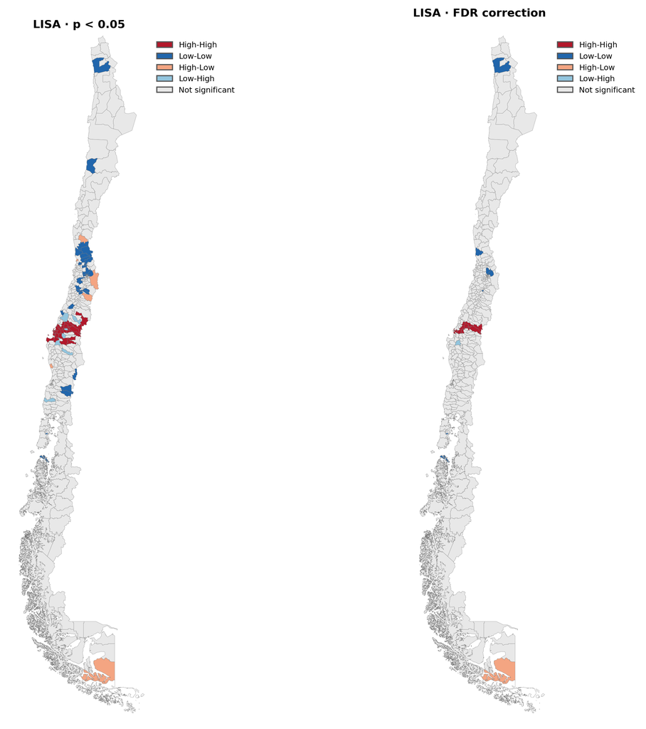

Figure 13: LISA clusters (queen contiguity, 999 permutations) for the smoothed standardised hospitalisation ratio of records 2019–2024: classification at p < 0.05 and with false discovery rate correction.

```python
lisa_rec = lisa.loc[(lisa.unit == "records") & (lisa.variable == "sir_eb"), ["cut_comuna", "cluster_p05", "cluster_fdr", "p_sim"]]
lisa_map = comunas_shp.merge(lisa_rec, on="cut_comuna", how="left")
fig, axes = plt.subplots(1, 2, figsize=(10, 9), layout="constrained")
cluster_map(axes[0], lisa_map, "cluster_p05", "LISA · p < 0.05")
cluster_map(axes[1], lisa_map, "cluster_fdr", "LISA · FDR correction")
plt.show()
```

**Show the code that produced this**

```python
sig = lisa.loc[(lisa.unit == "records") & (lisa.variable == "sir_eb") & (lisa.cluster_fdr != "No significativo")].copy()
sig = sig.merge(comunal.loc[comunal.unit == "records", ["cut_comuna", "region_short", "count", "asr", "sir_eb"]], on="cut_comuna", how="left")
show_table(sig.sort_values(["cluster_fdr", "value"], ascending=[True, False]).assign(cluster_fdr=lambda d: d.cluster_fdr.map(CLUSTER_LABELS))[[
    "comuna", "region_short", "cluster_fdr", "count", "asr", "sir_eb", "spatial_lag", "local_i", "p_sim"]].rename(columns={
    "comuna": "Commune", "region_short": "Region", "cluster_fdr": "Cluster (FDR)", "count": "Records", "asr": "ASR", "sir_eb": "Smoothed SHR",
    "spatial_lag": "Spatial lag", "local_i": "Local I", "p_sim": "p (permutations)"}),
    "Communes with significant local spatial association after false discovery rate correction (smoothed SHR, records 2019–2024)",
    {"ASR": 1, "Smoothed SHR": 2, "Spatial lag": 2, "Local I": 2, "p (permutations)": 3})
counts_lisa = lisa.loc[(lisa.unit == "records") & (lisa.variable == "sir_eb")].groupby(["cluster_p05"]).size().rename("p < 0.05").to_frame().join(
    lisa.loc[(lisa.unit == "records") & (lisa.variable == "sir_eb")].groupby(["cluster_fdr"]).size().rename("FDR"), how="outer").fillna(0).astype(int).rename(
    index=CLUSTER_LABELS).reset_index().rename(columns={"index": "Cluster", "cluster_p05": "Cluster"})
show_table(counts_lisa, "Number of communes by LISA cluster type according to the significance criterion")
```

Communes with significant local spatial association after false discovery rate correction (smoothed SHR, records 2019–2024)

| Commune | Region | Cluster (FDR) | Records | ASR | Smoothed SHR | Spatial lag | Local I | p (permutations) |
| --- | --- | --- | --- | --- | --- | --- | --- | --- |
| San Carlos | Ñuble | High-High | 198 | 80.1 | 2.75 | 1.53 | 7.08 | 0.001 |
| Chillán | Ñuble | High-High | 674 | 74.4 | 2.61 | 1.33 | 4.50 | 0.001 |
| San Nicolás | Ñuble | High-High | 38 | 74.3 | 2.27 | 1.94 | 8.58 | 0.001 |
| Talcahuano | Biobío | High-High | 425 | 61.6 | 2.18 | 1.79 | 6.87 | 0.001 |
| Penco | Biobío | High-High | 116 | 51.6 | 1.79 | 1.70 | 4.35 | 0.001 |
| Concepción | Biobío | High-High | 372 | 40.5 | 1.41 | 1.58 | 2.16 | 0.001 |
| Florida | Biobío | High-High | 19 | 42.1 | 1.39 | 1.41 | 1.58 | 0.001 |
| San Fabián | Ñuble | High-High | 9 | 49.2 | 1.38 | 1.73 | 2.44 | 0.001 |
| Ninhue | Ñuble | High-High | 9 | 45.9 | 1.35 | 1.49 | 1.67 | 0.001 |
| San Pedro de la Paz | Biobío | High-High | 259 | 34.8 | 1.22 | 1.63 | 1.49 | 0.002 |
| Coihueco | Ñuble | High-High | 46 | 34.5 | 1.19 | 1.91 | 1.88 | 0.001 |
| Quillón | Ñuble | High-High | 25 | 34.9 | 1.14 | 1.38 | 0.76 | 0.002 |
| Portezuelo | Ñuble | High-High | 6 | 29.5 | 1.07 | 1.62 | 0.81 | 0.001 |
| Ranquil | Ñuble | High-High | 7 | 29.1 | 1.02 | 1.53 | 0.54 | 0.001 |
| Timaukel | Magallanes | High-Low | 0 | 0.0 | 0.95 | 0.00 | 0.00 | 0.001 |
| Nacimiento | Biobío | Low-High | 24 | 19.1 | 0.69 | 1.44 | -0.63 | 0.001 |
| Puqueldón | Los Lagos | Low-Low | 3 | 21.5 | 0.80 | 0.00 | -0.00 | 0.001 |
| Guaitecas | Aysén | Low-Low | 0 | 0.0 | 0.66 | 0.00 | -0.00 | 0.001 |
| Huara | Tarapacá | Low-Low | 1 | 6.1 | 0.61 | 0.00 | -0.00 | 0.001 |
| Huechuraba | Metropolitana | Low-Low | 88 | 14.8 | 0.54 | 0.42 | 0.90 | 0.001 |
| Los Vilos | Coquimbo | Low-Low | 13 | 11.8 | 0.49 | 0.41 | 1.05 | 0.001 |
| Quinta de Tilcoco | O'Higgins | Low-Low | 5 | 8.6 | 0.44 | 0.41 | 1.19 | 0.001 |
| Colina | Metropolitana | Low-Low | 98 | 9.1 | 0.34 | 0.50 | 1.19 | 0.003 |
| Lo Barnechea | Metropolitana | Low-Low | 29 | 4.5 | 0.17 | 0.46 | 1.72 | 0.002 |
| Vitacura | Metropolitana | Low-Low | 14 | 3.2 | 0.15 | 0.44 | 1.85 | 0.001 |

Number of communes by LISA cluster type according to the significance criterion

| Cluster | p < 0.05 | FDR |
| --- | --- | --- |
| High-High | 31 | 14 |
| High-Low | 6 | 1 |
| Low-High | 8 | 1 |
| Low-Low | 41 | 9 |
| Not significant | 256 | 317 |

Significant positive autocorrelation indicates that communes with high ratios tend to neighbour other communes with high ratios. High-high clusters are concentrated in Ñuble and Biobío, around Chillán and Greater Concepción; low-low clusters in the Metropolitan Region, Valparaíso, O’Higgins and Coquimbo. The FDR-corrected reading reduces the clusters to the most robust ones: the Ñuble-Biobío core and a few low-ratio communes in the Metropolitan Region. These patterns describe the geography of hospital recording and are consistent with the organisation of the care network and with the catchment of the Chillán and Concepción hospitals.

# Part B. Hospital diagnostic trajectories

## B1. Question and definition

**Which hospital diagnoses appear before the first observed autism record, and when is it recorded as principal or secondary?**

The primary analysis uses the operational definition F84.0, F84.1, F84.5, F84.8 and F84.9 in any of the 35 diagnostic positions. All discharges of those identifiers are retrieved, including those without F84. Comparisons are also made with specific F84.0 and with historical F84.

The index date is the **first observed discharge** with the selected definition. Age refers to admission in that episode. The date of clinical diagnosis is unknown, and autism may have been diagnosed earlier, in outpatient care or outside the available period.

`DIAGNOSTICO1` is used operationally as the principal diagnosis and `DIAGNOSTICO2–35` as secondary diagnoses. A prior diagnosis may be a comorbidity, a symptom, an independent reason for admission or an alternative diagnosis. **The sequence of codes does not demonstrate that these were clinical differentials that were ruled out.**

**Show the code that produced this**

```python
kpis([
    (number(n_cohort), "Identifiers included · 2021–2024"),
    (number(n_prior), "With observable prior hospitalisations"),
    (number(cohort.age_median, 1), "Median age at first observed admission with ASD"),
])
```

**15,493**Identifiers included · 2021–2024

**2,617**With observable prior hospitalisations

**9.4**Median age at first observed admission with ASD

## B2. Identifier continuity

The 2019–2020 and 2021–2024 blocks **are not linked to each other**: they share no identifiers. The renaming of the field in 2024 does preserve matches with 2021–2023. The stability of the linkage and the semantics of diagnostic position require documentary confirmation from the data producer.

**Show the code that produced this**

```python
linkage = read_result("grd_linkage_between_years.csv")
show_table(linkage[["year_a", "year_b", "shared_identifiers", "comparable_ids", "agreeing_birth_and_sex", "pct_agreement"]].rename(columns={
    "year_a": "Start year", "year_b": "End year", "shared_identifiers": "Shared IDs",
    "comparable_ids": "Comparable IDs", "agreeing_birth_and_sex": "Concordant birth date and sex", "pct_agreement": "% agreement",
}), "Audit between pairs of years", {"% agreement": 2})
```

Audit between pairs of years

| Start year | End year | Shared IDs | Comparable IDs | Concordant birth date and sex | % agreement |
| --- | --- | --- | --- | --- | --- |
| 2019 | 2020 | 78,320 | 77,053 | 75,235 | 97.64 |
| 2019 | 2021 | 0 | 0 | 0 | — |
| 2019 | 2022 | 0 | 0 | 0 | — |
| 2019 | 2023 | 0 | 0 | 0 | — |
| 2019 | 2024 | 0 | 0 | 0 | — |
| 2020 | 2021 | 0 | 0 | 0 | — |
| 2020 | 2022 | 0 | 0 | 0 | — |
| 2020 | 2023 | 0 | 0 | 0 | — |
| 2020 | 2024 | 0 | 0 | 0 | — |
| 2021 | 2022 | 91,939 | 90,816 | 89,249 | 98.27 |
| 2021 | 2023 | 72,764 | 71,984 | 70,498 | 97.94 |
| 2021 | 2024 | 65,731 | 65,076 | 63,561 | 97.67 |
| 2022 | 2023 | 112,475 | 111,194 | 109,295 | 98.29 |
| 2022 | 2024 | 85,778 | 84,887 | 83,187 | 98.00 |
| 2023 | 2024 | 127,250 | 125,770 | 123,883 | 98.50 |

Agreement is calculated among identifiers without internal contradictions within each year and with comparable birth date and sex. On its own it does not demonstrate identity. No linkages are built from demographic data. The cohorts exclude identifiers with inconsistencies, invalid index dates or ambiguous episodes.

## B3. First record: principal or secondary

The following categories are mutually exclusive. “Principal and secondary” indicates codes of the definition in both positions of the same episode. “Mixed positions on the same day” keeps ties without imposing an arbitrary order.

**Show the code that produced this**

```python
positions = read_result("grd_first_position.csv")
pos = positions.loc[positions.definition == DEFINITION].copy()
pos["% of cohort"] = 100 * pos.patients / pos.groupby("era").patients.transform("sum")
pos["Position"] = pos.index_role.map(POSITION_LABELS)
show_table(pos[["era", "Position", "patients", "% of cohort"]].rename(columns={
    "era": "Period", "patients": "Identifiers",
}), "Position of the first hospital record of ASD", {"% of cohort": 2})
```

Position of the first hospital record of ASD

| Period | Position | Identifiers | % of cohort |
| --- | --- | --- | --- |
| 2019-2020 | Principal | 239 | 7.89 |
| 2019-2020 | Principal and secondary | 6 | 0.20 |
| 2019-2020 | Secondary only | 2,784 | 91.91 |
| 2021-2024 | Mixed positions on the same day | 1 | 0.01 |
| 2021-2024 | Principal | 678 | 4.38 |
| 2021-2024 | Principal and secondary | 15 | 0.10 |
| 2021-2024 | Secondary only | 14,799 | 95.52 |

**Show the code that produced this**

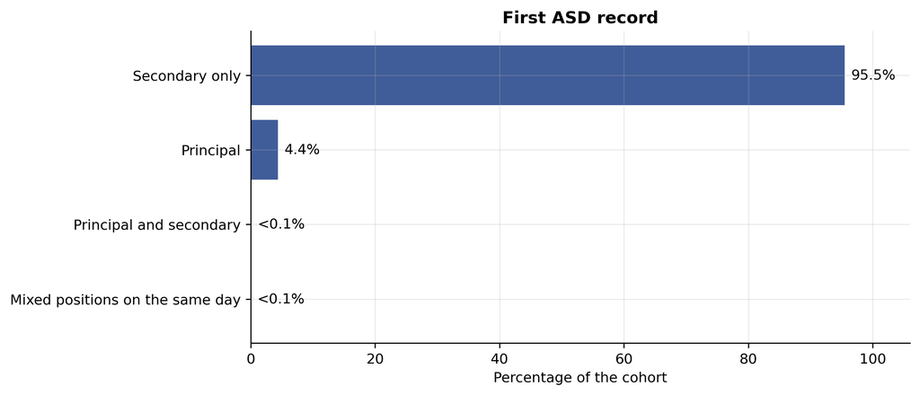

Figure 14: Position of the first observed hospital record, operational cohort 2021–2024.

```python
current = pos.loc[pos.era == ERA].sort_values("patients")
fig, ax = plt.subplots(figsize=(9, 3.8), layout="constrained")
ax.barh(current["Position"], current["% of cohort"], color=COLORS[1])
for i, value in enumerate(current["% of cohort"]):
    label = "<0.1%" if 0 < value < .1 else number(value, 1) + "%"
    ax.text(value + 1, i, label, va="center")
ax.set(xlabel="Percentage of the cohort", xlim=(0, 106), title="First ASD record")
plt.show()
```

## B4. Prior diagnoses

A strict prior diagnosis must **be discharged before admission to the index episode**. Contemporaneous or overlapping diagnoses are set apart. “No previous hospitalisations” means no hospital history observed in the period; it does not imply absence of symptoms or of outpatient diagnoses.

**Show the code that produced this**

```python
core["% with prior discharge"] = 100 * core.prior_hospitalization / core.patients
core["% with group of interest"] = 100 * core.prior_candidate_group / core.patients
show_table(core[["era", "patients", "prior_hospitalization", "% with prior discharge", "prior_candidate_group", "% with group of interest",
                 "days_first_prior_to_index_median"]].rename(columns={
    "era": "Period", "patients": "Cohort", "prior_hospitalization": "With prior discharge",
    "prior_candidate_group": "With prior group of interest", "days_first_prior_to_index_median": "Median days from first prior discharge to index admission",
}), "Observed prior diagnoses and time between contacts", {"% with prior discharge": 1, "% with group of interest": 1,
    "Median days from first prior discharge to index admission": 1})
```

Observed prior diagnoses and time between contacts

| Period | Cohort | With prior discharge | % with prior discharge | With prior group of interest | % with group of interest | Median days from first prior discharge to index admission |
| --- | --- | --- | --- | --- | --- | --- |
| 2019-2020 | 3,029 | 428 | 14.1 | 243 | 8.0 | 145.5 |
| 2021-2024 | 15,493 | 2,617 | 16.9 | 1,230 | 7.9 | 440.0 |

The time between contacts is not termed diagnostic delay. It is calculated only among those with a prior discharge.

### First observed hospital principal diagnosis

Includes the first discharge of each identifier within the period. It may be the index episode itself when there is no prior history. Distinct codes are kept in date ties.

**Show the code that produced this**

```python
first = selected(read_result("grd_first_hospital_principal.csv")).sort_values("patients", ascending=False)
first["% of cohort"] = 100 * first.patients / n_cohort
first["Description"] = first.code.str[:3].map(icd_label)
show_table(first[["code", "Description", "patients", "% of cohort"]].head(15).rename(columns={
    "code": "Principal code", "patients": "Identifiers",
}), "First observed principal · 15 most frequent codes · 2021–2024", {"% of cohort": 1})
```

First observed principal · 15 most frequent codes · 2021–2024

| Principal code | Description | Identifiers | % of cohort |
| --- | --- | --- | --- |
| N47 | Redundant prepuce, phimosis and paraphimosis | 735 | 4.7 |
| K358 | Acute appendicitis | 468 | 3.0 |
| F840 |  | 449 | 2.9 |
| J353 | Chronic diseases of tonsils and adenoids | 378 | 2.4 |
| G409 | Epilepsy | 342 | 2.2 |
| J46 | Status asthmaticus | 295 | 1.9 |
| F322 | Depressive episode | 227 | 1.5 |
| K353 | Acute appendicitis | 183 | 1.2 |
| K029 | Dental caries | 183 | 1.2 |
| A080 | Viral intestinal infections | 148 | 1.0 |
| J121 | Viral pneumonia | 145 | 0.9 |
| Q531 |  | 141 | 0.9 |
| R568 | Convulsions | 137 | 0.9 |
| J129 | Viral pneumonia | 135 | 0.9 |
| K352 | Acute appendicitis | 130 | 0.8 |

### Last principal diagnosis before the index

The denominator is the identifiers with any strict prior discharge. Not all of them necessarily have a principal diagnosis reported. Codes are shown normalised without the dot.

**Show the code that produced this**

```python
last = selected(read_result("grd_last_prior_principal.csv")).sort_values("patients", ascending=False)
last["% with prior discharge"] = 100 * last.patients / n_prior if n_prior else float("nan")
last["Description"] = last.code.str[:3].map(icd_label)
show_table(last[["code", "Description", "patients", "% with prior discharge"]].head(15).rename(columns={
    "code": "Last prior principal", "patients": "Identifiers",
}), "Last strictly prior principal · 2021–2024", {"% with prior discharge": 1})
```

Last strictly prior principal · 2021–2024

| Last prior principal | Description | Identifiers | % with prior discharge |
| --- | --- | --- | --- |
| N47 | Redundant prepuce, phimosis and paraphimosis | 80 | 3.1 |
| G409 | Epilepsy | 71 | 2.7 |
| J353 | Chronic diseases of tonsils and adenoids | 55 | 2.1 |
| J209 | Acute bronchitis | 41 | 1.6 |
| J46 | Status asthmaticus | 40 | 1.5 |
| K358 | Acute appendicitis | 40 | 1.5 |
| F322 | Depressive episode | 37 | 1.4 |
| J128 | Viral pneumonia | 36 | 1.4 |
| F603 | Specific personality disorders | 29 | 1.1 |
| J129 | Viral pneumonia | 29 | 1.1 |
| Q532 |  | 28 | 1.1 |
| J121 | Viral pneumonia | 28 | 1.1 |
| T432 | Poisoning by psychotropic drugs | 26 | 1.0 |
| A099 | Diarrhoea and gastroenteritis of presumed infectious origin | 25 | 1.0 |
| Z518 | Other medical care | 24 | 0.9 |

### Prior groups of interest

These are exploratory groupings, not confirmed differential diagnoses. An identifier counts once per group and window, but may contribute to several groups. The groups therefore cannot be added to obtain persons.

**Show the code that produced this**

```python
groups = selected(read_result("grd_previous_groups.csv"))
all_groups = groups.loc[(groups.window == "all") & (groups.position == "any")].sort_values("patients", ascending=False).copy()
all_groups["Group"] = all_groups.group.map(GROUP_LABELS)
all_groups["% of cohort"] = 100 * all_groups.patients / n_cohort
all_groups["% with prior discharge"] = 100 * all_groups.patients / n_prior if n_prior else float("nan")
show_table(all_groups[["Group", "patients", "% of cohort", "% with prior discharge"]].rename(columns={
    "patients": "Identifiers",
}), "Prior diagnostic groups, any position · 2021–2024", {"% of cohort": 1, "% with prior discharge": 1})
```

Prior diagnostic groups, any position · 2021–2024

| Group | Identifiers | % of cohort | % with prior discharge |
| --- | --- | --- | --- |
| Mood, anxiety and stress | 485 | 3.1 | 18.5 |
| Epilepsy | 382 | 2.5 | 14.6 |
| Developmental and speech signs | 224 | 1.4 | 8.6 |
| Language, learning and development | 222 | 1.4 | 8.5 |
| Childhood conduct and emotions | 152 | 1.0 | 5.8 |
| Intellectual disability | 142 | 0.9 | 5.4 |
| Hyperactivity and attention | 102 | 0.7 | 3.9 |
| Psychosis | 81 | 0.5 | 3.1 |
| Hearing | 75 | 0.5 | 2.9 |

### 365- and 730-day windows

The windows restrict **the dates of the prior diagnoses**; they do not select a cohort with complete observation of that duration. The denominator of the full cohort is retained, and the opportunity for observation is distinguished below.

**Show the code that produced this**

```python
window_groups = groups.loc[groups.position == "any"].pivot(index="group", columns="window", values="patients")
window_groups = window_groups.reindex(columns=["365d", "730d", "all"])
window_groups.index = window_groups.index.map(GROUP_LABELS)
window_groups = window_groups.rename_axis("Group").reset_index().rename(columns={
    "365d": "IDs in the previous 365 days", "730d": "IDs in the previous 730 days", "all": "IDs in the whole prior period",
})
show_table(window_groups, "Comparison of windows, any diagnostic position")
```

Comparison of windows, any diagnostic position

| Group | IDs in the previous 365 days | IDs in the previous 730 days | IDs in the whole prior period |
| --- | --- | --- | --- |
| Mood, anxiety and stress | 356 | 443 | 485 |
| Hearing | 45 | 64 | 75 |
| Childhood conduct and emotions | 93 | 131 | 152 |
| Intellectual disability | 95 | 124 | 142 |
| Epilepsy | 245 | 328 | 382 |
| Hyperactivity and attention | 67 | 87 | 102 |
| Language, learning and development | 133 | 185 | 222 |
| Psychosis | 56 | 75 | 81 |
| Developmental and speech signs | 125 | 189 | 224 |

### Recorded sequences

The sequence links the first observed principal, the last prior principal and the position of autism at the index. Only identifiers with prior history and without ties in the two previous stages are shown. The table does not represent the whole cohort, nor does it attribute a change of clinical diagnosis.

**Show the code that produced this**

```python
sequences = selected(read_result("grd_sequences.csv")).sort_values("patients", ascending=False)
sequences["Index position"] = sequences.index_role.map(POSITION_LABELS)
show_table(sequences[["first_principal", "last_prior_principal", "Index position", "patients"]].head(15).rename(columns={
    "first_principal": "First principal", "last_prior_principal": "Last prior principal", "patients": "Identifiers",
}), "Most frequent sequences among cases without prior ties")
```

Most frequent sequences among cases without prior ties

| First principal | Last prior principal | Index position | Identifiers |
| --- | --- | --- | --- |
| N47 | N47 | Secondary only | 65 |
| J353 | J353 | Secondary only | 46 |
| G409 | G409 | Secondary only | 44 |
| K358 | K358 | Secondary only | 37 |
| J209 | J209 | Secondary only | 30 |
| J46 | J46 | Secondary only | 28 |
| F322 | F322 | Secondary only | 27 |
| Q532 | Q532 | Secondary only | 25 |
| J128 | J128 | Secondary only | 21 |
| T432 | T432 | Secondary only | 19 |
| J351 | J351 | Secondary only | 18 |
| A099 | A099 | Secondary only | 17 |
| Q531 | Q531 | Secondary only | 16 |
| E101 | E101 | Secondary only | 16 |
| J121 | J121 | Secondary only | 15 |

## B5. Principal diagnosis of the episode when autism is secondary

These codes belong to the index hospitalisation. **They are contemporaneous**, not prior to autism. They describe the diagnosis occupying the principal position while ASD appears only in secondary positions.

**Show the code that produced this**

```python
index_codes = selected(read_result("grd_index_principal.csv"))
index_codes = index_codes.loc[index_codes.index_role == "solo_secundario"].sort_values("patients", ascending=False)
index_codes["Description"] = index_codes.code.str[:3].map(icd_label)
show_table(index_codes[["code", "Description", "patients"]].head(15).rename(columns={
    "code": "Principal code of the index", "patients": "Identifiers",
}), "Principal diagnosis of the index hospitalisation with ASD only secondary")
```

Principal diagnosis of the index hospitalisation with ASD only secondary

| Principal code of the index | Description | Identifiers |
| --- | --- | --- |
| N47 | Redundant prepuce, phimosis and paraphimosis | 718 |
| K358 | Acute appendicitis | 445 |
| J353 | Chronic diseases of tonsils and adenoids | 356 |
| G409 | Epilepsy | 353 |
| J46 | Status asthmaticus | 344 |
| F322 | Depressive episode | 243 |
| K029 | Dental caries | 191 |
| K353 | Acute appendicitis | 179 |
| J121 | Viral pneumonia | 166 |
| A080 | Viral intestinal infections | 161 |
| J129 | Viral pneumonia | 143 |
| R568 | Convulsions | 142 |
| J128 | Viral pneumonia | 135 |
| Q531 |  | 135 |
| K352 | Acute appendicitis | 129 |

## B6. Later transition from secondary to principal

A later episode must be admitted after the index discharge. The 365-day proportion uses only index episodes with at least 365 calendar days until the end of the period. Calendar availability does not attest to continuous clinical follow-up or to the absence of events outside the database.

**Show the code that produced this**

```python
transitions = read_result("grd_principal_transitions.csv")
transitions = transitions.loc[(transitions.definition == DEFINITION) & (transitions.index_role == "solo_secundario")].copy()
transitions["% principal within 365 days"] = 100 * transitions.later_principal_365d / transitions.eligible_followup_365d.replace(0, float("nan"))
show_table(transitions[["era", "patients", "later_principal", "eligible_followup_365d", "later_principal_365d", "% principal within 365 days",
                        "days_to_principal_median"]].rename(columns={
    "era": "Period", "patients": "Index secondary only", "later_principal": "Later principal observed",
    "eligible_followup_365d": "With 365 days available", "later_principal_365d": "Principal within 365 days",
    "days_to_principal_median": "Median days among those who transition",
}), "Transition to principal in another hospitalisation", {"% principal within 365 days": 2, "Median days among those who transition": 1})
```

Transition to principal in another hospitalisation

| Period | Index secondary only | Later principal observed | With 365 days available | Principal within 365 days | % principal within 365 days | Median days among those who transition |
| --- | --- | --- | --- | --- | --- | --- |
| 2019-2020 | 2,784 | 22 | 1,743 | 11 | 0.63 | 107.0 |
| 2021-2024 | 14,799 | 137 | 8,978 | 67 | 0.75 | 150.0 |

## B7. Distribution of the cohort by year, age and sex

These are first observed records in a hospital cohort, not incident diagnoses in the population. A larger number of records in a given year may reflect care contact or coding. Identifiers with demographic inconsistencies were excluded from the cohort.

**Show the code that produced this**

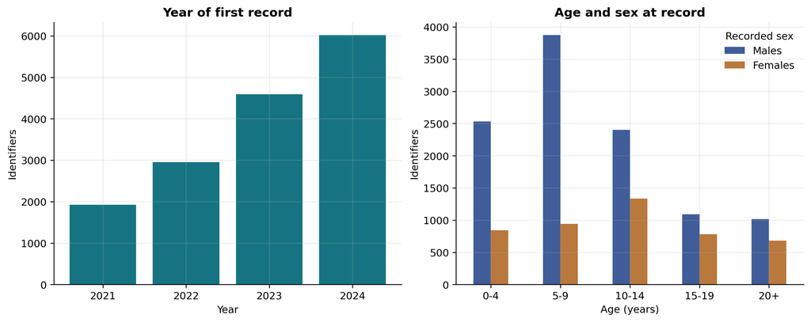

Figure 15: Operational cohort 2021–2024: year of first record and age distribution by sex.

```python
strata = selected(read_result("grd_cohort_strata.csv"))
by_year = strata.groupby("index_year").patients.sum()
by_age_sex = strata.groupby(["age_band", "sex"]).patients.sum().unstack("sex", fill_value=0).reindex(["0-4", "5-9", "10-14", "15-19", "20+"])
fig, axes = plt.subplots(1, 2, figsize=(11, 4.3), layout="constrained")
axes[0].bar(by_year.index.astype(str), by_year.values, color=COLORS[0])
axes[0].set(title="Year of first record", xlabel="Year", ylabel="Identifiers")
by_age_sex.rename(columns={"HOMBRE": "Males", "MUJER": "Females"}).plot.bar(ax=axes[1], color=[SEX_COLORS["HOMBRE"], SEX_COLORS["MUJER"]], rot=0)
axes[1].set(title="Age and sex at record", xlabel="Age (years)", ylabel="Identifiers")
axes[1].legend(title="Recorded sex")
plt.show()
```

**Show the code that produced this**

```python
sex_summary = strata.groupby("sex")[["patients", "prior_hospitalization", "prior_candidate_group"]].sum().reset_index()
sex_summary["% with prior discharge"] = 100 * sex_summary.prior_hospitalization / sex_summary.patients
sex_summary["% with prior group"] = 100 * sex_summary.prior_candidate_group / sex_summary.patients
sex_summary["sex"] = sex_summary.sex.map(SEX_LABELS)
show_table(sex_summary[["sex", "patients", "% with prior discharge", "% with prior group"]].rename(columns={
    "sex": "Recorded sex", "patients": "Identifiers",
}), "Prior diagnoses by sex, without adjustment for age or care contact", {"% with prior discharge": 1, "% with prior group": 1})
```

Prior diagnoses by sex, without adjustment for age or care contact

| Recorded sex | Identifiers | % with prior discharge | % with prior group |
| --- | --- | --- | --- |
| Males | 10,915 | 15.3 | 5.9 |
| Females | 4,578 | 20.8 | 12.8 |

## B8. Sensitivity to the case definition

Each definition recalculates its first date; the cohorts overlap and **are not additive**. Historical F84 includes Rett syndrome and other categories that must be distinguished when interpreting the results. The operational selection is not an automatic clinical equivalence with DSM-5.

**Show the code that produced this**

```python
sens_traj = summary[["era", "definition", "patients", "prior_hospitalization", "prior_candidate_group", "age_median"]].copy()
sens_traj["definition"] = sens_traj.definition.map(DEFINITION_LABELS)
show_table(sens_traj.rename(columns={
    "era": "Period", "definition": "Definition", "patients": "Included", "prior_hospitalization": "With prior discharge",
    "prior_candidate_group": "With prior group", "age_median": "Median age at record",
}), "Sensitivity to the case definition", {"Median age at record": 1})
```

Sensitivity to the case definition

| Period | Definition | Included | With prior discharge | With prior group | Median age at record |
| --- | --- | --- | --- | --- | --- |
| 2019-2020 | Specific autism (F84.0) | 1,956 | 234 | 125 | 8.8 |
| 2019-2020 | Operational ASD (F84.0/.1/.5/.8/.9) | 3,029 | 428 | 243 | 9.0 |
| 2019-2020 | Historical F84 (all subcategories) | 3,095 | 433 | 245 | 9.1 |
| 2021-2024 | Specific autism (F84.0) | 13,025 | 2,407 | 1,133 | 9.0 |
| 2021-2024 | Operational ASD (F84.0/.1/.5/.8/.9) | 15,493 | 2,617 | 1,230 | 9.4 |
| 2021-2024 | Historical F84 (all subcategories) | 15,628 | 2,637 | 1,242 | 9.4 |

## B9. Opportunity for observation and quality

A first record in 2021 may correspond to previously known autism. The following table separates available calendar time from evidence of a hospital contact at that distance. Neither condition demonstrates continuous clinical observation. The descriptive results above are not yet analyses restricted to complete 365/730-day periods.

**Show the code that produced this**

```python
show_table(core[["era", "patients", "lookback_365d", "lookback_730d", "observed_prior_365d", "observed_prior_730d"]].rename(columns={
    "era": "Period", "patients": "Included", "lookback_365d": "365 calendar days", "lookback_730d": "730 calendar days",
    "observed_prior_365d": "Contact at least 365 days before", "observed_prior_730d": "Contact at least 730 days before",
}), "Opportunity to observe prior diagnoses")

traj_quality = read_result("grd_trajectory_quality.csv")
show_table(traj_quality[["era", "raw_F84_identifiers", "F84_records_missing_id", "exact_duplicate_rows_removed",
                         "ids_inconsistent_or_missing_birth_sex", "ids_ambiguous_encounter_key", "history_records_invalid_dates"]].rename(columns={
    "era": "Period", "raw_F84_identifiers": "Initial F84 IDs", "F84_records_missing_id": "F84 records without ID",
    "exact_duplicate_rows_removed": "Exact duplicates removed", "ids_inconsistent_or_missing_birth_sex": "IDs with inconsistent or missing demographics",
    "ids_ambiguous_encounter_key": "IDs with ambiguous episode", "history_records_invalid_dates": "Records with invalid dates",
}), "Quality of the F84 universe before exclusions; causes may overlap")

show_table(summary[["era", "definition", "case_ids_before_qc", "patients", "case_ids_invalid_index_dates",
                    "index_same_day_ties", "concurrent_prior_records"]].rename(columns={
    "era": "Period", "definition": "Definition", "case_ids_before_qc": "IDs before checks", "patients": "IDs included",
    "case_ids_invalid_index_dates": "IDs with invalid F84 dates", "index_same_day_ties": "IDs with index tie",
    "concurrent_prior_records": "Overlapping records set apart",
}), "Inclusion and temporality by definition")
```

Opportunity to observe prior diagnoses

| Period | Included | 365 calendar days | 730 calendar days | Contact at least 365 days before | Contact at least 730 days before |
| --- | --- | --- | --- | --- | --- |
| 2019-2020 | 3,029 | 1,102 | 0 | 73 | 0 |
| 2021-2024 | 15,493 | 13,529 | 10,567 | 1,501 | 742 |

Quality of the F84 universe before exclusions; causes may overlap

| Period | Initial F84 IDs | F84 records without ID | Exact duplicates removed | IDs with inconsistent or missing demographics | IDs with ambiguous episode | Records with invalid dates |
| --- | --- | --- | --- | --- | --- | --- |
| 2019-2020 | 3,152 | 4 | 2 | 50 | 8 | 0 |
| 2021-2024 | 15,762 | 6 | 0 | 130 | 2 | 4 |

Inclusion and temporality by definition

| Period | Definition | IDs before checks | IDs included | IDs with invalid F84 dates | IDs with index tie | Overlapping records set apart |
| --- | --- | --- | --- | --- | --- | --- |
| 2019-2020 | autismo_F840 | 1,992 | 1,956 | 0 | 0 | 20 |
| 2019-2020 | TEA_operacional | 3,085 | 3,029 | 0 | 0 | 37 |
| 2019-2020 | F84_historico | 3,152 | 3,095 | 0 | 0 | 37 |
| 2021-2024 | autismo_F840 | 13,138 | 13,025 | 1 | 4 | 110 |
| 2021-2024 | TEA_operacional | 15,627 | 15,493 | 3 | 5 | 129 |
| 2021-2024 | F84_historico | 15,762 | 15,628 | 3 | 5 | 133 |

Records without an identifier cannot enter a trajectory. An identifier with more hospitalisations has more opportunities to accumulate diagnoses: age, sex, period and previous contacts must be considered before interpreting differences between groups. No causal models, survival analyses or population risks have been estimated.

# Summary

## Reproducibility and next extension

This QMD runs the descriptive statistics and figures in Python from the aggregated outputs of `scripts/grd_epidemiology.py`, `scripts/epi_rates.py` and `scripts/grd_trajectories.py`. The linkage audit comes from `scripts/audit_grd_linkage.py`. The dictionary of the derived tables is in `output_files/consolidacion/README.md` and the execution instructions are in the repository README.

The pending extensions are: confirming the linkage and the position semantics with the data producer, restricting the cohort by opportunity for observation, comparing principal/secondary position with adjustment for age, sex, year, contacts and hospital, incorporating deaths (DEIS) and emergency care, and validating a sample of clinical records to distinguish comorbidity, recording error and differential diagnosis.

Back to home Methods REM analysis